# Platform competition and strategic trade‐offs for complementors: Heterogeneous reactions to the entry of a new platform

Converted from PDF `Loh-PlatformCompetitionComplementors-2026-SMJ.pdf` · 59 pages · anchors: page `#pN`, block `#pN-bK`

Page 1

R E S E A R C H A R T I C L E

## Platform competition and strategic trade-offs for complementors: Heterogeneous reactions to the entry of a new platform

#### Johannes Loh<sup>1</sup> | Ambre Elsas-Nicolle<sup>2,3</sup>

1Department of Management and Organization, Vrije Universiteit Amsterdam, Amsterdam, Netherlands

2LMU Munich, Institute for Strategy, Technology and Organization, Munich, Germany

3Mines Paris, PSL University, CERNA, i3 UMR9217 CNRS, Paris, France

Correspondence Johannes Loh, Department of Management and Organization, Vrije Universiteit Amsterdam, De Boelelaan 1105, 1081 HV, Amsterdam, Netherlands. Email: j.loh@vu.nl

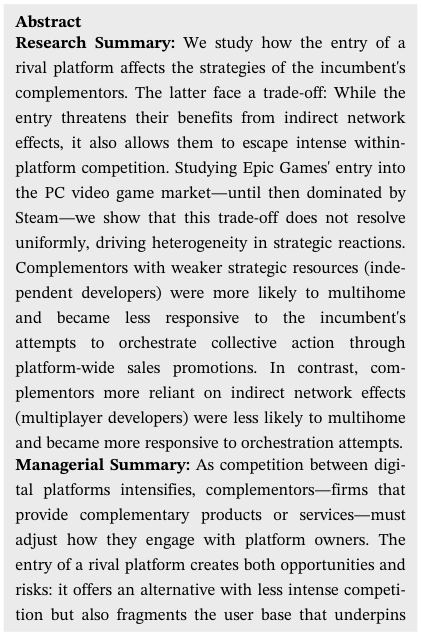

NOTE: figure/graphic rendered as an image from the PDF; its content is not machine-readable text. Caption (if any) follows as the next block.

**text found inside the figure**

Abstract Research Summary: We study how the entry of a rival platform affects the strategies of the incumbent's

complementors. The latter face a trade-off: While the

entry threatens their benefits from indirect network effects, it also allows them to escape intense within-

platform competition. Studying Epic Games' entry into the PC video game market—until then dominated by

Steam—we show that this trade-off does not resolve uniformly, driving heterogeneity in strategic reactions.

Complementors with weaker strategic resources (inde-

pendent developers) were more likely to multihome and became less responsive to the incumbent's

attempts to orchestrate collective action through platform-wide sales promotions. In contrast, com-

plementors more reliant on indirect network effects

(multiplayer developers) were less likely to multihome and became more responsive to orchestration attempts. Managerial Summary: As competition between digi-

tal platforms intensifies, complementors—firms that

provide complementary products or services—must adjust how they engage with platform owners. The

entry of a rival platform creates both opportunities and risks: it offers an alternative with less intense competi-

tion but also fragments the user base that underpins

Received: 23 August 2023 Revised: 10 November 2025 Accepted: 27 November 2025

DOI: 10.1002/smj.70062

This is an open access article under the terms of the Creative Commons Attribution License, which permits use, distribution and reproduction in any medium, provided the original work is properly cited. © 2026 The Author(s). Strategic Management Journal published by John Wiley & Sons Ltd.

Strat Mgmt J. 2026;47:1671–1729. wileyonlinelibrary.com/journal/smj 1671

Page 2

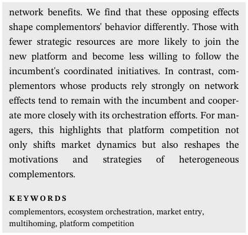

NOTE: figure/graphic rendered as an image from the PDF; its content is not machine-readable text. Caption (if any) follows as the next block.

**text found inside the figure**

network benefits. We find that these opposing effects shape complementors' behavior differently. Those with

fewer strategic resources are more likely to join the new platform and become less willing to follow the

incumbent's coordinated initiatives. In contrast, com-

plementors whose products rely strongly on network effects tend to remain with the incumbent and cooper-

ate more closely with its orchestration efforts. For managers, this highlights that platform competition not

only shifts market dynamics but also reshapes the motivations and strategies of heterogeneous

complementors.

K E Y W O R D S

complementors, ecosystem orchestration, market entry, multihoming, platform competition

#### 1 | INTRODUCTION

Competition between multi-sided platforms has sparked the interest of scholars and policymakers over the past decades (Rietveld & Schilling, 2020; Thatchenkery & Katila, 2022). These systems consist of a central firm—the platform owner—that connects complementors to consumers via an indirect network (Kretschmer et al., 2022). For example, app stores connect smartphone users to app developers, enabling transactions between them. Platforms exhibit strong economies of scale: a greater number of complementors increases consumer benefits through indirect network effects, resulting in a wider variety of complements (Rochet & Tirole, 2003, 2006). Platforms, therefore, rely on complementors for value creation (Agarwal et al., 2023; Loh & Kretschmer, 2023) and to successfully compete in the market (Shankar & Bayus, 2003). Consequently, scholars have studied owners' strategies to attract platform participants, such as pricing (e.g., Rochet & Tirole, 2003), exclusivity agreements (Cennamo & Santalo, 2013), or compatibility choices (Kretschmer & Claussen, 2016). Another stream discusses platform orchestration (and governance) as a determinant of market success, studying the rules and design features owners use to regulate and coordinate complementors' value creation (Claussen et al., 2013; Wareham et al., 2014).

However, we know less about the strategic choices made by complementors, despite their importance for platform-level outcomes. On the one hand, owners and complementors rely on each other for value creation (Jacobides et al., 2018). On the other hand, complementors are autonomous entities that pursue their own goals (Kretschmer et al., 2022), which may not always align with the owner's goals. While orchestration attempts aim to address such misalignment, complementors' agency remains a managerial challenge for platform owners. Put simply, complementors will only align their priorities with those of a platform only if it serves their own goals. This challenge is exacerbated by heterogeneity in complementor characteristics—such as market share or product-level network effects (Agarwal et al., 2023; Boudreau & Hagiu, 2009)—which increases the likelihood of diverging goals. Greater

1672 LOH and ELSAS-NICOLLE

Page 3

heterogeneity implies more varied needs and expectations, making goal alignment more difficult to achieve. Therefore, our understanding of how complementor agency and heterogeneity shape their strategic choices vis-à-vis platform owners remains limited.

In this paper, we investigate how complementors' strategic choices are shaped by platform market competition. Complementors are affected by platform-level outcomes in ambiguous ways (Panico & Cennamo, 2022). While a growing platform increases indirect network benefits, it also intensifies within-ecosystem competition as other complementors join (Boudreau & Jeppesen, 2015). In addition, many platform markets are dominated by a single player (Biglaiser & Crémer, 2020; Shapiro & Varian, 1998), which extracts most of the co-created ecosystem value (Rietveld et al., 2020). Hence, platform growth presents a double-edged sword for complementors. In turn, platform growth is a function of the level of competition platforms face in the market. Yet, how between-platform competition affects complementor behavior is a largely open question.

Therefore, we examine how complementors respond when a new platform enters a market previously dominated by a powerful incumbent. Complementors are impacted in opposing ways: while the entrant threatens indirect network benefits by luring consumers away from the incumbent,<sup>1</sup> it also constitutes an alternative with less intensive within-ecosystem competition. Complementors' reactions then depend on which of these “forces” dominates. This tension, however, is unlikely to resolve uniformly across heterogeneous complementor types. That is, some will primarily suffer from decreased network effects, while others will primarily benefit from a less competitive outside option in the entrant. To study the ambiguous implications for complementors' choices, we ask the following research questions: how does the entry of a rival platform affect (some of) the strategic choices complementors make? And how does this reaction differ across heterogeneous complementors?

We focus on two strategic choices: First, we investigate complementors' decision to multihome by joining the new platform. Before the entry, they had little choice but to affiliate only with the dominant incumbent. As multihoming is not costless (Cennamo et al., 2018), different complementor types will vary in their motivation to do so. Second, we study how the entry impacted complementors' responsiveness to one of the most salient incumbent's orchestration attempts. Specifically, we focus on complementors' willingness to participate in platform-wide sales, which are promotion periods aimed at coordinating collective discounts to create a concentrated period of high demand.<sup>2</sup> Sales promotions are a prominent way for platform owners to orchestrate collective action among complementors and to facilitate joint value creation (cf. Chen et al., 2022). While these sales aim to generate a temporary increase in platform demand, their effectiveness depends on complementors' (voluntary) participation. However, for complementors, this involves a tension. By participating, they invest in the “collective good” (cf. Cennamo & Santalo, 2019) of high platform demand, benefiting themselves and others. At the same time, they forgo using discounts as a competitive action in the complement market—after all, they discount at the same time as their competitors. Hence, sales participation reflects how complementors balance their pursuit of collective and individual interests. Furthermore, this balance can shift in reaction to changes in the external environment (cf. Klein et al., 2019), for instance, in the competitive landscape in the platform market (Abolfathi, 2025;

1We study a case of two (largely) non-interoperable platforms. Consumers cannot interact across platform boundaries, which makes network effects platform-specific. 2A well-known example is Amazon's Prime Days. Here, many products, including those from third-party sellers, are heavily discounted for a period of 2 days.

LOH and ELSAS-NICOLLE 1673

Page 4

Loh & Kretschmer, 2023). Sales promotions are also useful for studying this, as they constitute an orchestration tool subject to complementor participation that changes over time. Hence, studying complementors' repeated and dynamic choices regarding sales participation allows us to evaluate complementors' motivations to engage in collective action on a platform and how these are affected by changes in the level of between-platform competition. Lastly, we explore two dimensions of complementor heterogeneity, namely (i) their endowment with strategic resources and (ii) their reliance on network effects.

Empirically, we study the entry of Epic Games into the PC video game distribution market with the launch of its store in December 2018, which challenged the dominant position of incumbent platform Steam. This shift in the level of between-platform competition allows us to study the two strategic choices of interest for complementors in this setting, video game developers. That is, we investigate which complementor types were more likely to multihome by joining the Epic Games Store (EGS), and how the entry affected the rate at which they participated in Steam's platform-wide sales promotions, one of the incumbent's most prominent orchestration activities.

Our empirical results support our theoretical predictions. First, we find that complementors with weak strategic resources (independent developers) are more likely to multihome by joining the new platform. We attribute this to their struggle to prevail in the hyper-competitive incumbent ecosystem, which makes the prospect of less intense within-ecosystem competition on the entrant attractive. In contrast, complementors that are highly reliant on network effects (multiplayer developers) multihome at lower rates, as they depend on a unified consumer base on the incumbent. Second, we find that complementor heterogeneity drives variation in sales participation on the incumbent after the entry. Changes in between-platform competition shift how complementors balance their pursuit of collective and individual interests, leading to weakendowment complementors becoming less likely to participate in these sales after the entry, and those that are heavily reliant on network effects becoming more likely to do so. These findings contribute to the literature by showing how platform competition shapes complementors' strategic choices in nuanced and ambiguous ways, highlighting heterogeneity in their characteristics as a key determinant. We also discuss the implications of our findings for platform market entry and the effectiveness of platform orchestration.

#### 2 | THEORETICAL FRAMEWORK AND HYPOTHESES

#### 2.1 | Related literature

First, our paper connects to prior work on platform competition. Existing studies highlight how network effects shape platform adoption, market outcomes, and competitive strategies of platform owners (e.g., Cennamo & Santalo, 2013; Katz & Shapiro, 1985; Parker & van Alstyne, 2005). Yet, we know less about how such competition affects complementors. Recent work shows that the competitive standing of platforms influences complementors' activities and their value creation (Abolfathi, 2025; Loh & Kretschmer, 2023; Nagaraj & Piezunka, 2024; Thatchenkery & Katila, 2022), but it remains unclear how this translates into their strategic behavior. Second, we contribute to research on platform market entry. Network effects often create substantial incumbent advantages that deter entry (Biglaiser & Crémer, 2020), but entrants may succeed through higher quality, technological leapfrogging, or leveraging existing user bases (Eisenmann et al., 2011; Zhu & Iansiti, 2012). While prior studies have focused on

1674 LOH and ELSAS-NICOLLE

Page 5

incumbents' reactions to the entry of a new platform (Casadesus-Masanell & Zhu, 2010; Seamans & Zhu, 2014), little is known about how complementors strategically respond. Third, our study links to the literature on multihoming, where complementors join multiple platforms. Multihoming increases competitive pressure and reduces platform profits (Landsman & Stremersch, 2011), yet the drivers of complementors' decisions to multihome remain underexplored. While prior work has studied different platform characteristics (Cennamo et al., 2018; Hagiu & Lee, 2011), we know less about how heterogeneity in complementor characteristics drives the choice to join multiple platforms. Finally, our work relates to studies of platform orchestration (or governance), which examine how platform owners align complementors' activities through regulation, incentives, or collective initiatives (e.g., Boudreau, 2012; Rietveld et al., 2021; Wareham et al., 2014). Closest to our study, Rietveld et al. (2020) show that greater dominance enables platform owners to exercise more exploitative governance. Still, we know little about what drives complementors' compliance with governance practices and how between-platform competition relates to complementors' motivation to engage in collective action within the ecosystem. Hence, it is a largely open question how between-platform competition shapes the effectiveness of orchestration strategies.

#### 2.2 | Platform dominance and complementor heterogeneity

To analyze how an increase in between-platform competition affects the optimal strategic choices of complementors, we first discuss how a lack of platform-level competition impacts them. Platform dominance presents a double-edged sword for complementors (Panico & Cennamo, 2022). On the one hand, if consumer demand is concentrated in a single platform, complementors have access to the entire market there, maximizing indirect network effects (Shapiro & Varian, 1998). In contrast, if the consumer base is splintered across multiple platforms, the overall network benefit is diminished (Kretschmer, 2008).<sup>3</sup> On the other hand, supply-side platform growth increases the within-ecosystem competition each complementor faces (Boudreau & Jeppesen, 2015), which also allows dominant platform owners to extract a larger share of the value created (Rietveld et al., 2020). Thus, while platform dominance offers the greatest potential for indirect network effects, the intensified within-ecosystem competition makes it difficult for complementors to capture these benefits fully.

This tension is unlikely to resolve uniformly across complementors with heterogeneous characteristics (cf. Boudreau & Hagiu, 2009). While some primarily benefit from the network effects of a unified consumer base, others are primarily hurt by the hyper-competitive landscape on dominant platforms. We propose two sources of complementor heterogeneity that shape how this tension resolves. First, complementors vary in their endowment with strategic resources. Technological and human resources enable the creation of innovative, high-quality products (Paladino, 2007), brand reputation drives market success (Deephouse, 2000), and financial resources support sustained consumer engagement (Kunz et al., 2017). Such resources are essential to attaining a competitive advantage (Barney, 1991) in the complement market, and thus condition how complementors experience the trade-off between network benefits and competition on dominant platforms. Those with weak resource endowments are less able to prevail in such hyper-competitive contexts and therefore more likely to suffer from platform

3Note that splintering can be an efficient outcome under some conditions, such as a high degree of consumer heterogeneity.

LOH and ELSAS-NICOLLE 1675

Page 6

dominance. Second, complementors vary in their reliance on network effects. The returns to a larger consumer base vary, for example, when complement-level direct network effects are at play (Rietveld & Ploog, 2022). In this case, a larger demand side not only determines the potential market size, but it also directly affects the value of the complement to consumers.<sup>4</sup> Therefore, a complementor that is reliant on network effects experiences greater marginal returns to demand-side platform growth than other types. On a dominant platform, they are therefore more likely to experience a net benefit in the tension between network effects and competitive pressure.

#### 2.3 | Platform competition and strategic complementor choices

The dominance of an incumbent platform affects complementors in ambiguous ways. How, then, do they react when a new platform enters the market? Just as platform dominance presents a double-edged sword, so too does a challenge to it. On the one hand, the consumer base becomes splintered if some consumers move to the entrant. Because network effects arise from increasing returns to scale and the superadditivity of installed bases (Katz & Shapiro, 1994; Kretschmer, 2008), a splintered consumer base yields weaker network effects. Thus, the entry can harm complementors by undermining network benefits, even if they multihome across platforms. On the other hand, a new platform provides an alternative with less withinecosystem competition, as it initially hosts fewer other complementors (cf. Boudreau & Jeppesen, 2015). This gives complementors an opportunity to escape the incumbent's hypercompetitive landscape.

Consequently, the fate of complementors is closely tied to the structure of the platform market (Loh & Kretschmer, 2023; Nagaraj & Piezunka, 2024), and changes in its competitive landscape likely affect their strategic choices. While complementors make decisions across a wide range of variables, we focus on two. First, the entry of a rival platform lets complementors multihome. This expands market access by reaching consumers not affiliated with the incumbent (Belleflamme & Peitz, 2019), and complementors can partially escape the competitive pressure within the incumbent ecosystem. However, multihoming entails costs in compatibility investments (Cennamo et al., 2018), access fees (Armstrong, 2006), and added managerial effort across multiple customer bases. Complementors must weigh these costs and benefits when deciding whether to join the entrant. Given the ambiguous effects of between-platform competition, we expect heterogeneity in their multihoming decisions: those who are, on balance, harmed by the entry have less incentive to multihome, either because they benefit from a unified consumer base on the incumbent or because they can prevail in its competitive ecosystem. For others, the entrant is more likely to present an attractive outside option due to its less intense within-ecosystem competition.

Second, complementors' participation in platform-wide sales promotions is likely affected by the entry. These are limited periods during which the platform owner invites complementors to discount their products, creating a temporary surge in demand.<sup>5</sup> However, pricing and

4For example, Microsoft's Office Suite created direct network benefits for consumers through compatible file formats (e.g., XLS), which ease the sharing of documents. Before MS Office became available on other PCs (e.g., the Mac), its use was tied to MS Windows. Hence, users of Office (a complement) benefited from Microsoft's strong competitive standing in the operating system market (the platform). 5Prior literature examines the promotion of selected complementors by the platform owner (Agarwal et al., 2023; Rietveld et al., 2019). Our study differs because we are interested in complementor agency in the promotion choice.

1676 LOH and ELSAS-NICOLLE

Page 7

discounting decisions lie with complementors, so owners must orchestrate and incentivize sales participation. This reflects platform orchestration as a response to collective action problems (Chen et al., 2022), which arise from tensions between individual and collective interests (Bridoux & Stoelhorst, 2022). While complementors share a collective interest in high platformlevel demand (Cennamo & Santalo, 2019), they simultaneously compete for individual profits within the ecosystem (Boudreau & Jeppesen, 2015). Sales participation therefore represents a strategic trade-off: by participating, complementors invest in the collective interest of a high-demand period. At the same time, discounting their products in that way is not effective as a competitive action in the marketplace because they do so at the same time as their direct competitors.<sup>6</sup> Hence, they forgo their individual interest in outperforming other complementors. Consequently, sales participation reflects complementors' relative pursuit of collective versus individual interests.

Two mechanisms tie the entry of a rival platform to complementors' subsequent sales participation. First, while a dominant platform can use its influence to align complementors with its orchestration practices (Rietveld et al., 2020), a challenge to its dominance may foster resistance to such “take-it-or-leave-it” governance (Uzunca et al., 2022). Second, depending on whether the entry is beneficial or detrimental, the balance between complementors' pursuit of individual and collective interests on the incumbent may shift. If they benefit from the entrant's less competitive environment, contributing to the collective goal of a growing incumbent ecosystem may no longer align with their individual interests, leading to less sales participation.<sup>7</sup> Conversely, if complementors are primarily threatened by diminished network effects, they align more strongly with the collective interest of a growing and unified incumbent ecosystem, implying greater sales participation after entry. In sum, complementors' responses will vary with how they are affected by the entry.<sup>8</sup>

2.4 | Heterogeneous complementor reactions to the entry of a new platform

In the following section, we formulate hypotheses on how responses to the entry of the rival platform vary across different complementor types and the two strategic choices under investigation. We focus on complementors' endowment with strategic resources (Hypotheses 1a and 1b) and their reliance on network effects (Hypotheses 2a and 2b).

#### 2.4.1 | The role of complementors' resource endowment

Firms' ability to compete in the marketplace stems from the presence of strategic resources that are valuable, rare, inimitable, and non-substitutable (Barney, 1991), such as a strong reputation

6Research on product discounts highlights important limitations related to discount frequency, including potential adverse effects on consumer price sensitivity and future sales (Alba et al., 1999; Kopalle et al., 1999; Marshall & Bee Leng, 2002). As a result, complementors have to consider the timing and frequency of discounts carefully. 7This can also be the case for those that do not currently multihome, but whose consideration to do so might already trigger a sales participation response. 8In our study, we analyze the two decisions separately. However, it is plausible that these choices are interdependent. We explore this conjecture in Appendices A (Additional analysis: Interdependence of decisions—Does sales participation determine multihoming?) and B (Additional analysis: Interdependence between decisions—Does multihoming determine sales participation?).

LOH and ELSAS-NICOLLE 1677

Page 8

or brand, unique technological or managerial capabilities, or competent human resources (Helfat et al., 2023). We expect variation in resource endowment to influence complementors' reactions to the new platform's entry. For complementors that lack strategic resources, the detrimental effects of a hyper-competitive supply side outweigh the benefits of a greater demand side in the incumbent's ecosystem. Therefore, the entrant is an attractive alternative for this complementor type, due to its less intense within-ecosystem competition. Still, the entrant also hosts a smaller consumer side. Hence, complementors must evaluate both the absolute market size they encounter on the entrant and the share they are able to capture (Gans & Ryall, 2017). While all complementors face a smaller market size on the entrant, those with weaker resource endowment may find it more appealing due to reduced competition. The reason is that in highly crowded marketplaces, consumers cannot browse all available products (Dinerstein et al., 2018). This creates an issue for weak-endowment complementors more than for strong-endowment complementors, because the latter have ample resources to compete for attention (Meyer et al., 2024), regardless of the quality of their product. As a result, the prospect of joining the new platform creates the opportunity for weak-endowment complementors to gain greater attention there than they would in the crowded incumbent ecosystem. Although strong-endowment complementors can more easily afford the cost of joining the rival platform, they have much less to gain from it, as the potential gain in attention (and therefore in market share and performance there) is relatively lower than for weak-endowment types. As a result, the relative appeal of joining the entrant is expected to be greater for weak- than for strong-endowment complementors.<sup>9</sup> In other words, the trade-off between a less competitive outside option and potentially diminished indirect network effects is more likely to resolve in favor of joining the entrant for complementors with a weaker resource endowment. As a result, we expect weak-endowment complementors to be more likely to multihome (by joining the entrant) than those with a strong endowment. Furthermore, weakendowment complementors should also become less likely to participate in sales after the entry, as their interests shift away from the pursuit of the collective interest and toward the pursuit of their individual profitability on the incumbent. We therefore hypothesize:

Hypothesis 1a. (Multihoming): Complementors with a weak endowment of strategic resources are more likely to join the entrant than those with a strong endowment.

Hypothesis 1b. (Sales participation): Complementors with a weak endowment of strategic resources are less likely to participate in the incumbent's platform-wide sales promotions after the entry of the rival, compared to those with a strong endowment.

#### 2.4.2 | The role of complementors' reliance on network effects

Some complementors derive greater marginal returns from platform size than others (Rietveld & Ploog, 2022). In the case of complement-level network effects, a greater consumer side both provides indirect network benefits and directly determines a large part of a

9Note that this does not imply that only complementors with weaker resource endowment will perceive the entrant as attractive. Instead, the key point is that the relative attractiveness is greater for this type, which should result in systematic differences in the strength of their strategic responses.

1678 LOH and ELSAS-NICOLLE

Page 9

complement's value to consumers (Agarwal et al., 2023; Ploog & Rietveld, 2025).<sup>10</sup> We study the case where complement-level network effects do not operate across platform boundaries, which is common in several industries.<sup>11</sup> For example, video game console providers typically prevent their users from playing multiplayer games with users of other consoles, which makes the complement-level direct network effect of multiplayer games platform-specific.<sup>12</sup> In this case, the entrant is unattractive for complementors that are highly reliant on network effects: Not only does the entrant exhibit a smaller installed base of consumers, but it also threatens to splinter the network across multiple platforms. When the two platforms are not interoperable, this directly challenges the complement-level network effects, their value to consumers, and, in turn, the overall profitability of that type of complementor. Hence, this type is, in sum, more detrimentally affected by the entry, and they have less incentive to multihome by joining the entrant. After all, they are better off with a unified consumer base on the incumbent. At the same time, we expect this complementor type to become more likely to participate in sales on the incumbent after the entry. As they are highly reliant on a large consumer base, their individual interests are closely aligned with the collective interest of a greater and unified incumbent ecosystem. As the entry threatens to splinter the consumer base, we expect the interests of complementors that are highly reliant on network effects to shift even further toward alignment with the collective interest. Accordingly, we hypothesize:

Hypothesis 2a. (Multihoming): Complementors that are highly reliant on network effects are less likely to join the entrant than those that are less reliant on network effects.

Hypothesis 2b. (Sales participation): Complementors that are highly reliant on network effects are more likely to participate in the incumbent's platform-wide sales promotions after the entry of the rival, compared to those that are less reliant on network effects.

#### 3 | SETTING AND DATA

#### 3.1 | Institutional background

We empirically study the predictions from our theoretical framework in the context of the PC video game distribution market, where the dominant incumbent platform, Steam, was challenged

10Such a high reliance on network effects adds another dimension to the incumbency advantage in platform markets. This advantage stems from the incumbent's larger consumer base relative to the entrant (Biglaiser et al., 2019) and constitutes a significant barrier to entry. As a result, attracting complementors can be challenging for the entrant (Zhu & Iansiti, 2012). This is particularly true for complementors that rely on complement-level network effects and when platforms are not interoperable. 11In some cases, complement-level network effects are not platform-specific, and our arguments do not necessarily apply to them. For example, network effects among users of messaging apps such as WhatsApp operate across different mobile operating systems. In addition, recent years saw the emergence of “cross-play” functionality in the video game industry. In Appendix D (How the “cross-play” functionality could affect our study), we briefly discuss this development and explain why it does not pose a concern for our study. 12Similar dynamics apply to user reviews: more reviews generate informational benefits and thus app-level direct network effects, but only within the platform where they appear—for example, iPhone users see only App Store reviews, Android users only Google Play reviews. Other examples of platform-specific complement-level network effects include Netflix or Prime Video watch parties, ride-sharing options on Uber or Lyft, and data-driven improvements to recommendations.

LOH and ELSAS-NICOLLE 1679

Page 10

by the entry of a powerful competitor, the Epic Games Store. Video games are typically developed for one or several technology platforms such as the PC (22% of global market value in 2022<sup>13</sup>), smartphones and tablets (49%), or game consoles (29%).<sup>14</sup> In this paper, we focus on PC games. Initially sold in physical format, they are now mostly downloaded from online stores or played online.<sup>15</sup> The value chain comprises several key players, including game developers, publishers, hardware manufacturers, engine developers, and retailers. Game developers vary widely in size, ranging from large studios producing “Triple-A” games to smaller, independent ones, commonly referred to as “Indie” developers. While large developers were predominant in the early stages of the industry, digitization enabled the entry of many smaller players, resulting in an increased quantity and variety of products available in the market (Waldfogel, 2019).

The PC video game industry and Steam: Digital games are distributed through online platforms, which may be owned by publishers themselves (e.g., Ubisoft or EA's stores) or operated as marketplaces that host both first-party and third-party games, such as Steam and the Epic Games Store (EGS). Since its launch in 2003, Steam, owned by the American firm Valve, has remained the leader in the distribution of digital games, with about 130 million monthly active users in 2023, as shown in Figure 1a.<sup>16</sup> It offers a large variety of games from all genres, including both single- and multiplayer titles, from independent to large publishers such as Activision Blizzard or Microsoft. While a few games are first-party games,<sup>17</sup> most of the games offered on Steam are from third-party developers. These developers retain control over their product pricing, while the platform charges a transaction-based fee per sale.

1680 LOH and ELSAS-NICOLLE

Page 11

FIGURE 1 Evolution of the focal platforms: (a) Number of active users on each platform. Sources: Steam and EGS annual reports; (b) Number and duration of Steam

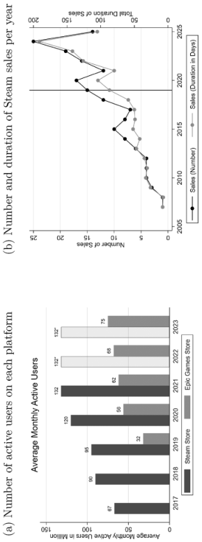

NOTE: figure/graphic rendered as an image from the PDF; its content is not machine-readable text. Caption (if any) follows as the next block.

sales per year. Source: SteamDB.

LOH and ELSAS-NICOLLE 1681

Page 12

We focus on sales participation as it provides a particularly informative lens on complementor responses to platform orchestration. Sales events are among the platform's most salient orchestration activities,<sup>20</sup> and participation in them represents a recurring, observable, and time-varying decision at the publisher or developer level, making it ideally suited for empirical analysis.<sup>21</sup> We argue that participation in platform-wide sales reflects complementors' willingness to align with the platform's orchestration efforts and their engagement in sustaining the broader health of the ecosystem.

Competitive landscape: Even though other digital stores were launched after Steam,<sup>22</sup> they are operated by major publishers, primarily distributing their own products. Access for thirdparty developers is typically limited, leaving few viable alternatives for independent and smaller developers to reach consumers. As a result, Steam maintained a dominant position in the PC game distribution market. By 2018, its market share was estimated to range between 50% and 70% (Wu & Zhang, 2019), confirming its position as the market leader. With about 26,000 games available at that time, the number of games offered on Steam has continued to grow steadily, reaching over 71,000 games at the end of 2023,<sup>23</sup> with more than 8000 new games released each year since 2018.<sup>24</sup>

In December 2018, Epic Games launched the Epic Games Store, a digital marketplace offering services similar to those of Steam. In addition to distributing third-party games, EGS also features a small number of first-party games, most notably the highly successful Fortnite. Despite a smaller initial user base, EGS quickly drew developer interest due to its favorable 12% revenue-share model. To expand its consumer and developer bases, Epic pursued two key strategies. It secured exclusivity agreements with major titles (e.g., Tom Clancy's The Division 2 in 2019)<sup>25</sup> and attracted users by offering a free game each week. Leveraging its ownership of the Unreal Engine (a widely used 3D computer graphics tool), Epic also stimulated adoption by waiving the engine's royalty fee for games sold through EGS, alongside its more generous revenue-sharing model (Wu & Zhang, 2019).

By the end of 2023, the Epic Game Store averaged over 75 million monthly active users, as shown in Figure 1a, and its catalog was approaching 3000 games. While Steam remains the largest player, EGS has established itself as a viable alternative, showing steady growth in both its consumer base and the number of affiliated complementors.<sup>26</sup>

Steam's reaction to Epic's entry: When facing the entry of a rival platform, an incumbent has several strategic tools at its disposal to mitigate competitive pressure and preserve the integrity of its established ecosystem. One such tool is pricing: the incumbent may adjust its revenuesharing model by lowering transaction fees or introducing a tiered pricing structure that favors some complementors—particularly those generating substantial demand. In addition to pricing, incumbents may respond by securing (additional) exclusivity agreements or expanding their in-

20Other key orchestration activities involve introducing social and community-oriented features. 21Another orchestration mechanism, studied in prior work (Rietveld et al., 2019, 2021), is the selective promotion of complementors, where platforms stimulate demand for certain complementors or complements through badges, quality seals, or paid placements. Steam, however, does not offer paid promotion. See https://partner.steamgames.com/doc/ marketing/visibility/. Instead, it relies on algorithmic visibility driven by popularity and quality metrics, preventing complementors from “buying” exposure. 22For example, Microsoft Store in 2005, Ubisoft's Uplay in 2012, and EA Origin in 2013. 23https://gamalytic.com/blog/steam-revenue-infographic. 24https://steamdb.info/stats/releases/. 25Some remained available through publishers' own channels, such as Ubisoft Connect, or on consoles. 26See Figures C7 and C8 in Appendix C for more details on the evolution of the number of users on Steam.

1682 LOH and ELSAS-NICOLLE

Page 13

house development of complementary products. In our setting, pricing appears to have been Steam's response. In November 2018, shortly before the launch of the Epic Games Store, Steam announced a shift to a tiered revenue-sharing model that offered more favorable terms to topselling games.<sup>27</sup> This strategy likely reflects an attempt to retain high-performing complementors in anticipation of increased platform competition.<sup>28</sup>

#### 3.2 | Data collection

27See https://steamcommunity.com/groups/steamworks/announcements/detail/1697191267930157838. 28Another possible response involves orchestration intensity, particularly sales events. Although Steam's sales frequency has generally increased (Figure 1b), this trend does not coincide with EGS's entry. However, we do observe a rise in targeted, non-regular promotions after 2018, which may reflect a competitive response (Figures C2 and C3, Appendix C). 29We used Stata's matchit command to create a “bridge dataset” that identifies, for each game, similarly named entries in the other dataset. We apply a similarity threshold of 0.8 using the Bigram string matching method. For all cases where the similarity score was below 1, we manually reviewed the suggested matches and selected the most appropriate one. If no suitable correspondence was found, the game was excluded from the sample. 30In the video game industry, the development studios create the game itself (game design, art, direction), while the publisher typically handles marketing, distribution, and financing. The release of a game thus reflects a vertical collaboration between these two entities. Importantly, the distinction between developer and publisher does not relate to our distinction between strongly and weakly endowed complementors. 31Steamdb.info continuously scrapes the Steam API, providing the full pricing history for the games in our sample. 32The site scrapes the Steam API daily to track active player counts for popular games.

LOH and ELSAS-NICOLLE 1683

Page 14

We also collected information from MobyGames.com, a comprehensive crowdsourced database that provides extensive information on all video games released for PC, home and portable consoles, and mobile devices (about 73,840 games). From this source, we retrieved information on each game's genre, release date, supported platforms (e.g., PC, PlayStation, iOS), number of staff members who worked on the game, and whether the game was developed with Epic's Unreal Engine. We complemented this with information from the Wikipedia category “Unreal Engine games.”<sup>33</sup> Finally, we collected critic scores data from Metacritic.

#### 4 | EMPIRICAL FRAMEWORK

We expect that platform entry influences complementors' strategies—some are more likely to multihome or engage in sales promotions than others. This section outlines how we operationalize these constructs and describes our empirical strategy.

#### 4.1 | Variables

#### 4.1.1 | Outcomes of interest

We analyze two strategic choices made by complementors. First, we analyze the determinants of multihoming, that is, their decision to join the entrant's platform in addition to the incumbent's. To test our first set of hypotheses, we use a binary dependent variable indicating whether a game became available on EGS after its launch. Second, we analyze how complementors' responsiveness to the incumbent's orchestration attempts changes after EGS's launch by studying their participation in Steam's sales promotions (i.e., Steam sales).<sup>34</sup> We argue that participation in these sales promotions reflects complementors' willingness to engage in collective action on the incumbent by making an investment into the “public good” of platform growth (Cennamo & Santalo, 2019). As such, we interpret complementors' participation in these events as indicative of the balance they strike between the pursuit of individual interests and alignment with collective goals.<sup>35</sup>

#### 4.1.2 | Heterogeneous complementor types

In our hypotheses, we formulate expectations about how different types of complementors respond to the entry of a rival platform. In particular, we highlight the role of their resource

33See https://en.wikipedia.org/wiki/Category:Unreal_Engine_games. 34As explained above, these promotional periods semi-regularly take place on the platform. Steam invites, but does not force, game developers to participate in these sales by discounting their games for a certain duration. 35As also noted earlier, developers also pursue individual objectives when discounting their games. However, during platform-wide sales, they coordinate the timing of discounts with others, limiting their use as a competitive tool. To further support our interpretation of sales participation as a response to orchestrated collective action, we conduct a mechanism test in Appendix B (Additional analysis: Discounts outside sales). Specifically, we find no change in discounting behavior outside promotional periods following the entrant's launch, suggesting that complementors adjust their behavior only in response to the incumbent's orchestration efforts, which is consistent with a shift in the balance between individual and collective interests.

1684 LOH and ELSAS-NICOLLE

Page 15

endowment and reliance on network effects. Empirically, we classify game developers into distinct types that capture these dimensions.

Strong vs. weak resource endowment (Hypotheses 1a and 1b): Similar to the movie and music industries, video game producers can be roughly divided into major (“Triple-A”) and independent (“Indie”).<sup>36</sup> The most salient differentiating factor between the two is their endowment with resources, financial and others. Triple-A games are produced with substantially larger development budgets, which are expected to exceed 1 billion US Dollars in the near future (Zollner, 2023). These resources enable the formation of large development teams,<sup>37</sup> investments in cutting-edge technologies to produce high-fidelity games, and the development of inhouse marketing capabilities that support highly effective promotional efforts. In contrast, indie games—while not a clearly defined term—are commonly associated with “simple gameplay, simple graphics, small teams” (Dutton, 2012). In addition, Triple-A developers operate large legal departments, allowing them to engage in direct negotiations with platform owners such as Steam. This grants them considerable “persuasive resources” (Ryall, 2013) as well. Accordingly, we capture variation in resource endowment via the distinction between Triple-A and Indie developers. We therefore test our first hypothesis using a binary variable that identifies games developed by Indie developers, representing complementors with weak resource endowment.

High vs. low reliance on network effects (Hypotheses 2a and 2b): Some games offer functionalities that allow consumers to play together online. These multiplayer games are subject to complement-level network effects (Rietveld & Ploog, 2022), which makes them more reliant on a large, unsplintered consumer base.<sup>38</sup> Without such a unified network, multiplayer games are unable to fully realize their value potential. This is in contrast to singleplayer games, which are played individually and therefore exhibit less dependence on a large consumer base. Accordingly, we capture reliance on network effects using a binary variable indicating multiplayer games.

#### 4.2 | Empirical approach: Multihoming analysis

In this part of our analysis, the dependent variable is a binary indicator of multihoming, defined as a game's affiliation with the entrant's platform (EGS) by the end of our observation period— approximately 3 years after the entry took place. We expect the probability of multihoming to be higher for Indie than non-Indie games (Hypothesis 1a) and lower for multiplayer than singleplayer games (Hypothesis 2a).

Sample: Because we are interested in how the incumbent's complementors respond to the entry of a rival, we restrict our analysis to games available exclusively on Steam or on both Steam and EGS, excluding those available only on EGS. We also excluded games developed by Valve, the firm that owns and operates Steam. We define multihoming as the decision by a developer to make a game available on EGS at any point between December 2018 (the launch of EGS) and June 2022 (when data collection concluded). Our final sample, for which all

36Examples of Triple-A developers include Electronic Arts and Activision Blizzard, known for popular game franchises like FIFA Football and Call of Duty. Indie developers are typically smaller and less well-known, though notable examples include Hello Games (No Man's Sky), Supergiant Games (Hades), and Larian Studios (Baldur's Gate 3). 37In our data, the average number of credited development staff is 117 for major studios, and only 16 for indie games. 38Our argument rests on the assumption that network effects are platform-specific. That is, consumers can only play games together using the same platform. Please see our additional discussion in Appendix D (How the “cross-play” functionality could affect our study).

LOH and ELSAS-NICOLLE 1685

Page 16

variables are available, consists of a cross-section of 8101 games, of which 7.06% are multihoming.<sup>39</sup>

Regression model and identification: We estimate a logit model in which the dependent variable takes the value of one if game i has also joined EGS by June 2022, and zero otherwise. A value of zero can be interpreted as the developer's decision to remain exclusive to Steam, despite EGS having been available for over 3 years. Importantly, joining EGS is a one-off decision for each game, resulting in no within-unit variation over time. As such, we have to resort to a cross-sectional analysis. This approach introduces the challenge that games are not randomly assigned to the types we are interested in (that is, Indie and multiplayer). These types are likely to be correlated with other structural attributes that also influence multihoming decisions, raising concerns about endogeneity due to an omitted variable bias. To address this concern, we implement a combination of strategies, including control variables, fixed effects, and matching techniques, as detailed below. We model the decision to multihome as follows:

Multihomingi = α + β1 × Indie + β2 × Multiplayer + β3Xi + γg +γr + ϵi:

Multihomingi is a binary variable coded as one if the game is available on both platforms and zero otherwise. The terms Indie and Multiplayer are binary indicators capturing the game types relevant to our hypotheses. The main coefficients of interest are β1 and β2, which correspond to Hypotheses 1a and 2a, respectively. We also include two sets of fixed effects and a range of controls to address the aforementioned endogeneity concerns. First, we include genre fixed effects, denoted by γg, to account for variation in competitive intensity across market segments.<sup>40</sup> Second, we also include release year fixed effects, denoted γr, to capture life cycle dynamics.<sup>41</sup>

The vector Xi includes a set of control variables designed to account for potential lock-in effects and other factors that might influence a developer's multihoming decision. To capture experience on the incumbent platform, we include the number of games previously released on Steam by both the developer and the publisher. In addition, Steam offers a range of standardized features that developers can incorporate into their games,<sup>42</sup> which can further “tie” the game to the platform. For each of these features, we include a binary indicator of whether the game utilizes it. In contrast, the availability of games on home consoles may indicate a lower degree of platform-specific lock-in. We, therefore, include a dummy indicating whether the game was released on any major console. We also include a dummy variable indicating whether a game was developed with Epic's Unreal Engine. Since Epic offers preferential revenue-sharing terms on EGS for such titles, using the engine may provide an additional incentive to multihome.

Finally, we include a set of variables to proxy for a game's quality and popularity. Here, we control for its price (a higher price may indicate higher quality and possibly higher demand),

39In addition to our main analysis at the game level, we also investigate multihoming choice at the firm level, as detailed in Appendix A (Robustness check: Intensity of multihoming at the publisher level). 40A game's genre may influence its multihoming decision through differences in audience size, pricing levels, or saturation levels, making it a potential confounding factor if not properly controlled for. 41For example, games typically generate the majority of their sales within the first 12 months after release (Claussen et al., 2012). Consequently, older games may have less to gain from joining the entrant platform. 42These features include community engagement tools, network-effect functionalities, and cloud-based services.

1686 LOH and ELSAS-NICOLLE

Page 17

the average number of active players (a higher number indicates greater popularity),<sup>43</sup> and the size of the development team (as a proxy for its production costs). In addition, we include a dummy variable indicating whether a game features in-app purchases, as such games may rely on recurring revenue streams.<sup>44</sup> Also, for the subsample of games released prior to the launch of EGS, we can control for the number of user reviews accumulated on Steam up to that point, as well as the share of positive reviews. These serve as further controls for a game's popularity and quality.<sup>45</sup>

#### 4.3 | Empirical approach: Sales participation analysis

In Hypotheses 1b and 2b, we make predictions about how the launch of the EGS affects complementors' participation in the incumbent's sales promotions. We expect the probability of participation to decrease for Indie games (weak resource endowment, Hypothesis 1b) and increase for multiplayer games (high reliance on network effects, Hypothesis 2b). We test our hypotheses within a difference-in-difference (DiD) framework. Throughout, the dependent variable is a binary indicator equal to one if game i participated in a Steam sale s, and zero otherwise. We, therefore, estimate how the probability of sales participation differs between the periods before and after the launch of EGS, and how this change varies across different game types.

Sample: In our main specification, we restrict the sample to a 2-year window, that is, 1 year before and 1 year after the launch of EGS, in order to account for seasonal effects. During this period, Steam held 27 sales events.<sup>46</sup> Some were highly specialized while others were broader, leading to wide variation in participation rates (ranging 0.13%–75.17%). To focus on the main events, we include only sales with at least 1% of games participating in our main specification.<sup>47</sup>

This leaves us with a total of 18 Steam sales, out of which seven took place in the year before EGS's launch and 11 afterwards. Furthermore, since we are interested in how complementors' incentives to participate in orchestration activities evolve, we restrict the sample to the 4191 games already available on Steam at the start of the observation period. Then, the unit of observation in our regressions is a game–sale; that is, we observe each game during the period of each sale in our sample and evaluate whether it participated in that sale. Our final regression sample consists of 75,179 game–sale observations.

Regression model and identification: We face several empirical challenges. First, to test our hypotheses, we use two different “treatment” indicators in our DiD framework: Indie and multiplayer games. Therefore, we face empirical challenges because we estimate differences across game types that may not be comparable in terms of their tendency to participate in Steam sales.<sup>48</sup> Such differences may also affect their ability to optimally react to EGS's launch. We control for such differences in two ways: (i) we include game fixed effects throughout to account

43This is an imperfect measure because the average is calculated over a game's entire lifetime up to the time of our data collection. In some cases, it includes player counts from after the game had joined EGS. 44This could discourage developers from splitting their user base across multiple platforms, particularly when network externalities or community engagement are important. 45Our main results are robust to using these variables in a matching procedure rather than including them as controls. We describe and discuss this alternative strategy in Appendix A (Robustness check: Coarsened exact matching). 46Table B1, in the Appendix, presents the list of all 27 sales. 47Results are robust to alternative thresholds, including all sales or those with at least 5% participation. 48For example, multiplayer games may rely relatively more on “in-game” monetization (via in-app purchases) compared to singleplayer games, which may drive their inherent tendency to participate in sales.

LOH and ELSAS-NICOLLE 1687

Page 18

for unobserved and time-invariant differences in their participation tendencies, (ii) we run our regressions using matched samples to further control for observed performance and quality differences.

A second challenge arises from heterogeneity across different Steam sales. As noted above, some target broader sets of games than others. In addition, the platform determines both the timing and the nature of sales events, which may be driven by strategic considerations. Most importantly, the launch of the EGS may have prompted the organization of additional sales to keep consumers on the incumbent.<sup>49</sup> We account for these potential confounding factors by including sale fixed effects (e.g., “Winter Sale 2018”) throughout our analysis. That is, our estimates can be understood as the probability of a game participating in a sale, conditional on the nature of the sale itself, which is unobserved by us. This approach also accounts for games' average tendency to participate in a sale, which is likely a function of how many sales take place within a certain time period. In our setting, Steam organized more sales after EGS's launch, which may have made game developers more selective about which ones to participate in. Together, we estimate econometric models of the following form:

Y is = α + βi Afters × Ti ð Þ + βXXis + γi + γs + ϵis:

Here, Y is is our dependent variable, a binary indicator equal to one if game i participated in sale s, and zero otherwise. After s indicates sales that took place after the launch of EGS, and Ti is our “treatment” indicator for a specific game type. In addition to fixed effects, we also include a vector of four time-varying game-level control variables, denoted Xis. First, we control for the total number of Steam reviews a game has received by the time of a sale, using this as a proxy for its prior market performance in the absence of direct sales data. Second, we control for the share of positive “thumbs up” reviews to capture differences in perceived game quality. Third, we control for a game's age (in days) to capture unobserved differences in their tendency to participate in sales, which may vary over their life cycle. Fourth, we include the number of games in the same genre available on Steam, reflecting the level of within-ecosystem competition a game faces based on its market positioning.<sup>50</sup> Next, γi and γs are game and sale fixed effects. Note that the latter also controls for unobserved time trends.<sup>51</sup>

Lastly, we run part of our analysis on matched samples.<sup>52</sup> Specifically, we use coarsened exact matching (CEM) based on the control variables in Xis, but measured at the time of EGS's launch.<sup>53</sup> Therefore, we only compare (i) Indie to non-Indie and (ii) multiplayer to singleplayer that exhibit similar performance, audience reception, age, and intra-platform competition.<sup>54</sup>

49Some evidence is presented in Appendix C, in Figures C1–C3. 50For games assigned to multiple genres, we sum the number of other games across all relevant genres and divide this total by the number of genres the focal game belongs to, yielding an average measure of competitive intensity. 51We assess the possibility of non-parallel pre-trends in Appendix B (Pre-trends in sales participation). While participation rates differ across sales, they do not differ significantly across complementor types. 52This serves as a more conservative alternative to our time-varying controls in Xis. It ensures that our coefficients only reflect differences between games that are otherwise comparable in their relevant observed characteristics. 53The only difference is that we match on the games' release year instead of their age in days. 54We assess the effectiveness of our matching strategy by testing for differences in means across the matching variables before and after matching in Appendix B (Matching procedure: Differences in means).

1688 LOH and ELSAS-NICOLLE

Page 19

#### 5 | RESULTS

#### 5.1 | Multihoming analysis

#### 5.1.1 | Descriptive statistics

Turning to the variables that capture potential sources of lock-in on Steam, we find that, on average, developers have released approximately three games on the platform, while publishers have released around 10.<sup>56</sup> Furthermore, the share of games incorporating Steam features

TABLE 1 Multihoming analysis: Summary statistics.

| Variable | Obs. | Mean | Std dev. . | Min. | Max. |
| --- | --- | --- | --- | --- | --- |
| Multihoming | 8101 | 007 . | 026 . | 0 | 1 |
| Indiegame | 8101 | 061 . | 049 . | 0 | 1 |
| Multiplayergame | 8101 | 03 . | 046 . | 0 | 1 |
| GamedevelopedwithUnrealEngine | 8101 | 004 . | 019 . | 0 | 1 |
| NumberofgamesbythesamedeveloperonSteam | 8101 | 31 . | 616 . | 1 | 72 |
| NumberofgamesbythesamepublisheronSteam | 8101 | 1022 . | 1717 . | 1 | 93 |
| GamehasSteamWorkshop | 8101 | 008 . | 027 . | 0 | 1 |
| GamehasSteamAchievements | 8101 | 064 . | 048 . | 0 | 1 |
| GamehasSteamCloud | 8101 | 046 . | 05 . | 0 | 1 |
| GamehasSteamLeaderboard | 8101 | 012 . | 033 . | 0 | 1 |
| GamehasSteamTradingCards | 8101 | 04 . | 049 . | 0 | 1 |
| Availableforhomeconsoles | 8101 | 032 . | 047 . | 0 | 1 |
| AveragepriceonSteaminUSDollars | 8101 | 1492 . | 1226 . | 0 | 12999 . |
| AveragenumberofplayersonSteam | 8101 | 81348 . | 1415318 , . | 0 | 95099919 , . |
| Teamsize | 8101 | 5962 . | 22589 . | 0 | 4413 |
| In-app purchases | 8101 | 002 . | 015 . | 0 | 1 |
| Pre-entry review count (in 1000s) | 4456 | 324 . | 2486 . | 0 | 138408 . |
| Pre-entry share of positive reviews | 4426 | 078 . | 017 . | 0 | 1 |

NOTE: table converted from PDF layout to HTML text; cell boundaries are reconstructed. See PDF if exact alignment matters.

55Appendix A (Additional descriptive statistics: Timing of multihoming) provides additional descriptive statistics on the timing and sequence of multihoming. Furthermore, Appendix C (Additional descriptive statistics: Differentiation of platforms) presents additional descriptive evidence on platform differentiation, including comparisons of prices, genre distributions, and audience socio-demographics between Steam and EGS. 56For both, this number follows a power-law distribution, with a few developers and publishers having released a high number of games while many have released only a few.

LOH and ELSAS-NICOLLE 1689

Page 20

ranges between 8% for “Workshop” to 64% for “Achievements.”<sup>57</sup> This variation likely reflects both the specificity of each feature and the relative ease of implementation. In addition, around one-third of games are also available for at least one home console.<sup>58</sup> Finally, 4% of games in our sample have been developed using Epic's Unreal Engine.

Next, we turn to the control variables related to game quality and popularity. The average game on Steam is priced at 14.92 USD,<sup>59</sup> though pricing varies widely—from free-to-play titles to games priced as high as 129.99 USD. On average, games have 813.48 concurrent active players.<sup>60</sup> The average development team consists of 59.62 individuals. In terms of monetization, 2% of games use in-app purchases, which enable consumers to acquire additional content or assets during gameplay. Finally, for the sample of games released before EGS's launch, we observe an average of 3240 user reviews per game, with 78% of them being positive.

#### 5.1.2 | Main results

Table 2 presents the results from our main analysis of complementors' multihoming decisions. Throughout, we report average marginal effects, which reflect percentage point changes in the

TABLE 2 Multihoming analysis: Main results.

|  | (1) | (2) | (3) | (4) | (5) |
| --- | --- | --- | --- | --- | --- |
| Hypothesis1a:Indiegame | −0 .0051 | 00346 . | 00320 . | 00313 . | 00298 . |
|  | (00058) . | (00072) . | (00072) . | (00072) . | (00072) . |
| Hypothesis2a:Multiplayergame | 00019 − . | 00196 − . | −0 .0159 | −0 .0156 | 00112 − . |
|  | (00061) . | (00065) . | (00063) . | (00073) . | (00072) . |
| Genredummies |  |  |  | Y | Y |
| Releaseyeardummies |  |  | Y |  | Y |
| Controls |  | Y | Y | Y | Y |
| Observations | 8101 | 8101 | 8101 | 8101 | 8101 |
| MeanDV | 00706 . | 00706 . | 00706 . | 00706 . | 00706 . |
| Pseudo-R2 | 00265 . | 0196 . | 0229 . | 0205 . | 0238 . |

NOTE: table converted from PDF layout to HTML text; cell boundaries are reconstructed. See PDF if exact alignment matters.

Note: Robust standard errors in parentheses. The unit of observation is a game. The dependent variable is a dummy indicating if the game multihomes at the end of our observation period. All models are estimated using logit specifications, and average marginal effects are reported. All models use the full sample of games.

57The “Workshop” feature enables user-generated game modifications and the “Achievements” feature allows users to display their in-game accomplishments on their profile. 58Home consoles are, for example, Sony PlayStation or Nintendo Switch. While these platforms are usually considered a distinct market from PC gaming (e.g., Clements & Ohashi, 2005), the presence of games on these platforms suggests that (some) developers are not strongly locked into Steam. 59Based on prices listed on the U.S. version of the Steam storefront, we also collected price and sales information from the UK, EU, and Japanese versions, which do not exhibit meaningful differences for our analyses. 60However, this number also follows a power law distribution, with some games exhibiting no active players at all and others averaging nearly one million.

1690 LOH and ELSAS-NICOLLE

Page 21

probability that a game multihomes. Models 1 through 5 progressively incorporate control variables and fixed effects. We focus our discussion on Model 5, which includes the complete set of controls and fixed effects. First, we find strong support for Hypothesis 1a: Indie games are 2.98 percentage points (SE = 0.0072) more likely to multihome than non-Indie games. This result is consistent with the idea that Indie developers are more inclined to shift their value creation to the entrant's ecosystem, which is, at least initially, less competitive. Given the sample mean of 7.06% of multihoming games, this is also an economically sizable effect. Second, we also find support for Hypothesis 2a. The estimated coefficient for multiplayer games is negative and statistically significant in most specifications, suggesting that these games are less likely to multihome compared to singleplayer ones. However, the effect is slightly smaller (β = −0.0112) and estimated with lower precision (SE = 0.0072) in Model 5, which includes release-year fixed effects. This may indicate the presence of dynamic effects. To explore this possibility, we conducted an additional analysis focusing on the timing of multihoming (see Appendix A, Additional analysis: Timing of multihoming).

#### 5.1.3 | Additional analyses

We conducted a series of additional analyses to test the robustness and underlying mechanisms of our main results. Appendix A contains the full details. First, we analyze the timing of multihoming using hazard models based on release dates across platforms (Appendix A, Additional descriptive statistics: Timing of multihoming and Additional analysis: Timing of multihoming). Consistent with our main results, indie games are more likely to multihome and do so more quickly than major games. In addition, multiplayer games are less likely to multihome and do so less quickly than singleplayer games. Second, to examine the role of switching costs, we split the sample by release date relative to EGS's entry (Appendix A, Additional analysis: Games released before and after the EGS launch). Results are consistent with our main findings. Third, we investigate whether multihoming depends on game quality and popularity (Appendix A, Additional analysis: Pre-EGS quality and popularity of games). While higher user ratings (quality) are positively related to multihoming for all game types, the number of ratings (popularity) matters most for indie games. While consistent with our theoretical arguments, this adds nuance to our main findings, and we discuss this in greater detail in the appendix. Fourth, we also explore whether developers' decisions to multihome depend not only on individual game characteristics but also on their interaction. Results from the interaction model suggest a nuanced pattern: the effect of being an indie game remains strongly positive and significant when the game is not multiplayer, but the combination of indie and multiplayer characteristics yields a smaller and statistically insignificant effect. This suggests that the effect of the indie characteristics on multihoming is “attenuated” when the game also offers multiplayer features (Appendix A, Additional analysis: Interaction between games characteristics). Fifth, we examine whether multihoming is related to greater sales participation before the entry, that is, whether the two decisions are interrelated (Appendix A, Additional analysis: Interdependence of decisions—Does sales participation determine multihoming?). We found no evidence to support that conjecture. Sixth, we explore variation in within-ecosystem competition as a potential determinant of multihoming (Appendix A, Additional analysis: Multihoming and within-genre competition). As the competitive landscapes (based on genres) are very similar across the two platforms, we do not find evidence for an effect. Lastly, we provide additional robustness tests by using coarsened exact matching (Appendix A, Robustness check: Coarsened exact matching)

LOH and ELSAS-NICOLLE 1691

Page 22

and by examining firm-level, instead of game-level, multihoming (Appendix A, Robustness check: Intensity of multihoming at the publisher level), both of which yield results similar to our main findings.

#### 5.2 | Sales participation analysis

#### 5.2.1 | Descriptive statistics

Table 3 presents descriptive statistics for our main sample. On average, 38% of games participate in sales. Additionally, sales increase in the period following the launch of EGS compared to before. In fact, as illustrated in Figure 1b, Steam increased the number of sales per year between 2017 and 2020. This may be a reaction to the launch of EGS, and we address this issue by including sale-fixed effects throughout.

Next, 49% of our games in the sample were developed by Indie developers, resulting in a roughly even split for this treatment group, and 36% offer multiplayer functionality. In terms of time-varying control variables, games have an average of 4130 reviews at the time of a sale, and 77% are positive. Moreover, the average game is 1518 days old.<sup>61</sup> Furthermore, the average game faces competition from 1639 others in the same genre within Steam.<sup>62</sup>

TABLE 3 Sales participation analysis: Summary statistics.

|  | Obs. | Mean | Std dev. . | Min. | Max. |
| --- | --- | --- | --- | --- | --- |
| Regressionanalysis |  |  |  |  |  |
| Participationtosales | 75179 , | 038 . | 049 . | 0 | 1 |
| After | 75179 , | 061 . | 049 . | 0 | 1 |
| Indiegame | 75179 , | 049 . | 050 . | 0 | 1 |
| Multiplayer(MP)game | 75179 , | 036 . | 048 . | 0 | 1 |
| GamedevelopedwithUnrealEngine | 75179 , | 003 . | 018 . | 0 | 1 |
| Reviewcount(1000s) | 75179 , | 413 . | 2885 . | 0 | 170209 . |
| Positivereviewshare | 75179 , | 077 . | 017 . | 0 | 1 |
| Gameage(days) | 75179 , | 151848 . | 106370 . | 23 | 8196 |
| Intra-competition measure | 75179 , | 163924 . | 58518 . | 16 | 2758 |
| Matching |  |  |  |  |  |
| Reviewcountatentry | 4191 | 396824 . | 2718976 , . | 0 | 1384079 , , |
| Positivereviewshareatentry | 4176 | 077 . | 017 . | 0 | 1 |
| Intra-competition measure at entry | 4191 | 156717 . | 51009 . | 21 | 2270 |
| Gamereleaseyear | 4191 | 201442 . | 286 . | 1997 | 2017 |

NOTE: table converted from PDF layout to HTML text; cell boundaries are reconstructed. See PDF if exact alignment matters.

61This relatively high number is driven by a handful of very old but still popular games. 62We also use coarsened exact matching (CEM) in parts of our analysis. There, we match on our control variables, measured at the time of EGS's launch. At that point, the average game had 3968.24 reviews (77% were positive), had been released in 2014, and faced intra-platform competition from 1567.17 other games.

1692 LOH and ELSAS-NICOLLE

Page 23

#### 5.2.2 | Main results

The main results of our sale participation analysis are presented in Table 4. Throughout, we estimate linear probability models, as they allow for two-way fixed effects and let us include and interpret interaction terms in a straightforward manner. Standard errors are clustered at the game level. In Hypothesis 1b, we hypothesized that complementors with a weak resource endowment are less likely to participate in sales after EGS's launch than those with a strong endowment. We test this hypothesis in Models 1, 3, and 4, and we find consistent support. In Model 1, which uses the full sample without matching and only includes the DiD term interacted with the Indie game indicator, we find that the probability of sale participation is 1.4 percentage points (SE = 0.0048) lower for Indie games after EGS's launch, compared to non-Indie games. In Model 3, we run a full model, including the DiD terms involving the multiplayer indicator. We still find support for Hypothesis 1b, albeit with a slightly smaller coefficient (β = −0.0117) that is estimated with slightly lower precision (SE = 0.0048). Finally, in Model 4, instead of using time-varying controls, we estimate our model using a matched sample.<sup>63</sup>

That is, each Indie game is only compared to non-Indie games of similar performance, audience reception, age, and facing similar intra-competition. Such a match is found in only 3021 games, reducing the sample size. Still, Hypothesis 1b is again supported with an even larger estimated effect size: Indie games are 2.04 percentage points less likely to participate in Steam sales after EGS's launch, compared to non-Indie games (SE = 0.0067).

TABLE 4 Sales participation analysis: Main results.

|  | Fullsample |  |  | CEM |  |
| --- | --- | --- | --- | --- | --- |
|  | (1) | (2) | (3) | (4) | (5) |
| Hypothesis1b:After × Indiegame | 00140 − . |  | −0 .0117 | 00204 − . |  |
|  | (00048) . |  | (00048) . | (00067) . |  |
| Hypothesis2b:After × MPgame |  | 00258 . | 00246 . |  | 00254 . |
|  |  | (00049) . | (00050) . |  | (00068) . |
| GameFE | Y | Y | Y | Y | Y |
| SteamsaleFE | Y | Y | Y | Y | Y |
| Controls | Y | Y | Y |  |  |
| Observations | 75179 , | 75179 , | 75179 , | 54378 , | 55314 , |
| Games | 4191 | 4191 | 4191 | 3021 | 3073 |
| MeanDV | 0384 . | 0384 . | 0384 . | 0398 . | 0394 . |
| Adjusted R -squared | 05768 . | 05769 . | 05769 . | 05787 . | 05716 . |
| Within-R2 | 0000574 . | 0000831 . | 0000913 . | 0000254 . | 0000374 . |

NOTE: table converted from PDF layout to HTML text; cell boundaries are reconstructed. See PDF if exact alignment matters.

Note: Robust standard errors in parentheses are clustered at the game level. The unit of observation is a game-sale. The dependent variable is a dummy indicating that the game participated in a sale. All estimations use linear probability models and include game and sale fixed effects. Models 1–3 use the full sample of games. Models 4 and 5 use a sample of matched games (CEM). A constant is included but not reported.

63Note that it is impossible to estimate effects on a matched sample with all three relevant DiD terms. The reason is that the CEM weights have to be obtained for each treatment group indicator separately.

LOH and ELSAS-NICOLLE 1693

Page 24

#### 5.2.3 | Additional analyses

We ran additional analyses to explore the robustness of our findings on sales participation and the underlying mechanisms. Detailed results are provided in Appendix B. First, we distinguish between major and minor sales, based on the number of participating games (Appendix B, Additional analysis: Minor versus major sales). We find that effects are driven by minor sales, which suggests that complementors continue participating in high-visibility sales but become more selective in engaging with smaller-scale sales. Second, we analyze how the entry affected discounting outside Steam's sales promotions (Appendix B, Additional analysis: Discounts outside sales), and do not find any effects. Hence, we are confident in interpreting our main results as a reaction in terms of complementors' responsiveness to orchestration attempts.<sup>64</sup> Third, we explore the possible interaction between our focal complementor characteristics (i.e., Indie and multiplayer), which are not mutually exclusive and may give rise to conflicting predictions (Appendix B, Additional analysis: Interaction between games characteristics). Our results suggest that no “type” dominates the other. Fourth, we examine if post-entry sales participation is determined by multihoming, that is, if the two choices are interrelated (Appendix B, Additional analysis: Interdependence between decisions—Does multihoming determine sales participation?). We do not find any evidence to support this claim. Finally, we show that games with higher pre-EGS popularity (review count) and quality (review score) are more likely to participate in sales after the entry (Appendix B, Additional analysis: The role of pre-EGS review count and score). While this adds nuance to our main findings, we consider it fully consistent with our theoretical arguments.

64We conducted additional analyses to assess the impact of the entry on prices across different complementor types in Appendix C (Additional analysis: Impact of the entry on prices). Here, we do not find any impact of games' current prices (i.e., discounted or undiscounted). However, we do find a significant change in list prices (i.e., undiscounted). Indie games tended to increase their prices after the entry (in particular those that multihome), while multiplayer games tended to decrease them. This may indicate that developers use these prices to steer demand across platforms in ways that are consistent with our theoretical arguments.

1694 LOH and ELSAS-NICOLLE

Page 25

#### 6 | DISCUSSION AND CONCLUSION

We investigate how the level of between-platform competition shapes complementors' strategic choices. Specifically, we examine how the entry of a powerful rival platform challenged an incumbent's dominance and influenced (i) complementors' decision to multihome by joining the rival, and (ii) their participation in the incumbent's platform-wide sales promotions— reflecting their responsiveness to orchestration attempts and willingness to engage in collective action within the incumbent's ecosystem. The entry of a rival platform affects the motivations behind these choices in ambiguous and heterogeneous ways. On the one hand, it threatens the network benefits complementors derive on the incumbent, reducing their profitability. On the other hand, it offers an opportunity to escape the intense within-ecosystem competition on the incumbent. How this tension resolves determines complementors' multihoming and sales participation decisions. However, because complementors differ in their needs and characteristics, the resolution is not uniform: some are primarily harmed by diminished network benefits, whereas others mainly benefit from an alternative for value creation with less within-ecosystem competition. We develop and test hypotheses about how different types of complementors respond to entry, focusing on two sources of heterogeneity: their endowment with strategic resources and their reliance on network effects.

Empirically, we study our research questions in the PC video game distribution market, where the dominant incumbent platform, Steam, faced the entry of a powerful rival, the Epic Games Store. We find broad support for our hypotheses: For complementors with weaker resource endowment (Indie developers), the opportunity of a less competitive alternative outweighed the potential loss in indirect network effects. They therefore became more likely to multihome by joining the entrant and less likely to participate in the incumbent's sales promotions, indicating reduced responsiveness to its orchestration attempts. Conversely, complementors that are highly reliant on network effects (multiplayer developers) are primarily threatened by diminished network benefits. Consequently, they were less likely to multihome and became more likely to participate in the incumbent's sales promotions.<sup>65</sup>

#### 6.1 | Implications

Our findings have several implications for both platform owners and complementors. First, the level of platform competition is a key determinant of complementors' strategic choices. This is due to the complex and often ambiguous interdependencies between platforms and their complementors. While platform owners' success relies on the support of complementors, the reverse is less straightforward: Not all complementors benefit equally from platform success because the tensions between network effects and within-ecosystem competition do not resolve uniformly across heterogeneous complementors. As a result, complementors differ in their profitmaximizing strategies, such as platform affiliation and compliance with orchestration.

Second, our findings have implications for firms seeking to enter platform markets. The well-known “chicken-and-egg” problem (Caillaud & Jullien, 2003) limits initial network

65Further analyses highlight that complementors' responses to a rival platform's entry depend on the interaction between their resource endowment and reliance on network effects. See the results presented in Appendices A (Additional analysis: Interaction between games characteristics) and B (Additional analysis: Interaction between games characteristics).

LOH and ELSAS-NICOLLE 1695

Page 26

benefits and hinders the adoption of new platforms by complementors and consumers. Yet, our findings suggest that entrants can use a “divide-and-conquer” strategy that targets specific types of complementors early on. In particular, complementors with a weak resource endowment are more likely to join the entrant, as they benefit from reduced within-platform competition. At the same time, this implies that new platforms would initially attract a peculiar set of complementors, which may be of lower value individually and contribute to the platform's niche character. This also implies challenges for incumbents. While network effects generally raise entry barriers, they may not be sufficient to deter all threats, as increasing within-ecosystem competition can drive some complementors to seek alternatives. This finding adds nuance to the value of “incumbency advantage” in platform markets (Biglaiser & Crémer, 2016).

Finally, our findings also contribute to policy discussions around platform dominance. The heterogeneous reactions of complementors to the entry highlight that their welfare is tied to the platform-level market structure in complex and ambiguous ways. Consequently, antitrust remedies aimed at “breaking up” large platforms may not yield uniform benefits for all complementors. In particular, those relying on unified consumer bases would be adversely affected. As such, regulatory interventions should account for the diversity of complementor interests and the trade-offs they face in platform environments.

#### 6.2 | Contributions

We make several contributions to the platform literature. First, prior studies on platform competition have focused on strategic choices made by platform owners (e.g., Cennamo & Santalo, 2013; Jin & Rysman, 2015; Seamans & Zhu, 2014; Seamans & Zhu, 2017), but only a little attention has been paid to the choices made by complementors—a crucial determinant of platforms' competitive performance. Our contribution lies in analyzing how the platform-level market structure affects complementors' strategic choices, thereby advancing our understanding of their role in driving and responding to between-platform competition.

Second, we contribute by showing that heterogeneity in complementor characteristics leads to variation in their likelihood to multihome. Prior literature has generally been limited in its exploration of the determinants of multihoming, with only a few studies analyzing platformlevel factors (Cennamo et al., 2018; Hagiu & Lee, 2011). We expand this perspective by highlighting complementor-level factors. Our findings also inform a broader discussion on the relationship between multihoming and platform competition (e.g., Armstrong, 2006; Landsman & Stremersch, 2011)—differences in complementors' incentives to multihome determine their prevalence, which in turn determines the intensity of competition across platforms.

Third, we highlight how complementor-level factors can determine successful entry into platform markets. While prior studies have focused on platform-level attributes and strategies (e.g., Seamans & Zhu, 2014; Zhu & Iansiti, 2012), our paper shows how complementor characteristics (resource endowment and reliance on network effects) shape their incentives to support a new platform. Thus, we contribute to the literature by showing how heterogeneity among complementors influences the dynamics of platform market entry.

Finally, our study contributes to the literature on platform orchestration (or governance). Prior work has emphasized how platform owners design and implement governance mechanisms. Still, it has largely overlooked the agency of complementors in complying with governance attempts (Abou-El Komboz et al., 2023). We contribute by highlighting that successful governance is determined not only by the actions of platform owners but also by the

1696 LOH and ELSAS-NICOLLE

Page 27

heterogeneous motivations of complementors. In particular, we show that this is partly shaped by the level of competition between platforms. This also complements prior research explaining how platform dominance influences governance practices by owners (Rietveld et al., 2020). Hence, we contribute by showing that market structure is a critical determinant of the effectiveness of platform orchestration.

#### 6.3 | Limitations and future research

Our study also has several limitations. First, we only study reactions to the entry of the EGS by complementors on Steam, the largest and most prominent platform in the PC video game distribution market, but not other platforms.<sup>66</sup> Our focus is justified by data availability (on Steam) and by the fact that Epic's entry constitutes a particularly salient market shift. Still, future research should provide a more comprehensive analysis of how cross-platform competitive dynamics shape complementor strategies. Second, we focus on two specific strategic choices made by complementors. However, they make a broader set of strategic choices (e.g., pricing and positioning) that are also likely to respond to platform competition and offer promising avenues for future research. Third, for our study of product-level network effects, it is important to note that we study a context where the two platforms are not interoperable on the consumer side. This means that network effects do not operate across platforms. However, in other settings, this can differ, namely when competing platforms are interoperable and complementlevel network effects extend across platforms.<sup>67</sup> The mechanisms described in our paper might not hold in such cases, and complementors' strategic responses to platform market entry may differ. Studying a case without interoperability thus constitutes a clear boundary of our work, and we leave it to future research. Finally, our empirical setting exhibits some peculiarities that may limit the generalizability of our results. We therefore encourage future research to replicate and extend our approach in a broader range of empirical settings.

ACKNOWLEDGMENTS The authors are grateful to the Editor, Claudio Panico, and two anonymous reviewers for their helpful guidance throughout the review process. We also thank Paolo Aversa, Ralf Elsas- Nicolle, Aldona Kapaˇcinskaitė, Tobias Kretschmer, Hakan Özalp, and Juan Santalo for their valuable comments and suggestions. We thank Yannick Keuker for his excellent research assistance. This paper has benefited from feedback received during conference presentations at the Strategy Science Conference (2023), AFREN Digital Economics Conference (2023), Paris Conference on Digital Economics (2023), VU Ecosystems Day (2024), Digital Platform Ecosystems Forum (2024), European Digital Platform Research Network Summit (2023), Academy of Management Annual Meeting (2023), and Strategic Management Society Annual Conference (2024), as well as from seminar presentations at BI Norwegian Business School, Julius-Maximilians- Universität Würzburg, University of Galway, PLAMADISO Seminar Series, Rotterdam School of Management, Université Paris Nanterre, and Vrije Universiteit Amsterdam.

66Such as Good Old Games, which focuses on offering games free of digital rights management as well as larger publishers' own distribution platforms. 67Examples include messaging services or social media apps, where users can interact regardless of the platform they use.

DATA AVAILABILITY STATEMENT The data that support the findings of this study are available from the corresponding author upon reasonable request.

ORCID Johannes Loh https://orcid.org/0000-0002-5344-6941 Ambre Elsas-Nicolle https://orcid.org/0000-0001-5014-4457

REFERENCES

Abolfathi, N. (2025). Multihoming and single-homing complementors' responses to intensified between-platform

competition: Evidence from the youtube–twitch rivalry. Strategic Management Journal, 47(1), 141–188. Abou-El Komboz, L., Kerkhof, A., & Loh, J. (2023). Platform partnership programs and content supply: Evidence

from the YouTube “Adpocalypse”. Working Paper. Agarwal, S., Miller, C. D., & Ganco, M. (2023). Growing platforms within platforms: How platforms manage the

adoption of complementor products in the presence of network effects? Strategic Management Journal, 44(8), 1879–1910. Alba, J. W., Mela, C. F., Shimp, T. A., & Urbany, J. E. (1999). The effect of discount frequency and depth on con-

sumer price judgments. Journal of Consumer Research, 26(2), 99–114. Armstrong, M. (2006). Competition in two-sided markets. The Rand Journal of Economics, 37(3), 668–691. Barney, J. (1991). Firm resources and sustained competitive advantage. Journal of Management, 17(1), 99–120. Belleflamme, P., & Peitz, M. (2019). Platform competition: Who benefits from multihoming? International Jour-

nal of Industrial Organization, 64, 1–26. Benfell, G. (2024). PC cross-play is required for all multiplayer games on epic games store, epic confirms. Games-

pot (September 11). https://www.gamespot.com/articles/pc-cross-play-is-required-for-all-multiplayer-gameson-epic-games-store-epic-confirms/1100-6526425/ Biglaiser, G., Calvano, E., & Crémer, J. (2019). Incumbency advantage and its value. Journal of Economics &

Management Strategy, 28(1), 41–48. Biglaiser, G., & Crémer, J. (2016). The value of incumbency in heterogeneous platforms. CESifo Working Paper,

No. 5829. Biglaiser, G., & Crémer, J. (2020). The value of incumbency when platforms face heterogeneous customers.

American Economic Journal: Microeconomics, 12(4), 229–269. Boudreau, K. J. (2012). Let a thousand flowers bloom? An early look at large numbers of software app developers

and patterns of innovation. Organization Science, 23(5), 1409–1427. Boudreau, K. J., & Hagiu, A. (2009). Platform rules: Multi-sided platforms as regulators. Platforms, Markets and

Innovation, 1, 163–191. Boudreau, K. J., & Jeppesen, L. B. (2015). Unpaid crowd complementors: The platform network effect mirage.

Strategic Management Journal, 36(12), 1761–1777. Bridoux, F., & Stoelhorst, J. (2022). Stakeholder governance: Solving the collective action problems in joint value

creation. Academy of Management Review, 47(2), 214–236. Caillaud, B., & Jullien, B. (2003). Chicken & egg: Competition among intermediation service providers. RAND

Journal of Economics, 4(2), 309–328. Casadesus-Masanell, R., & Zhu, F. (2010). Strategies to fight ad-sponsored rivals. Management Science, 56(9),

1484–1499. Cennamo, C., Ozalp, H., & Kretschmer, T. (2018). Platform architecture and quality trade-offs of multihoming

complements. Information Systems Research, 29(2), 461–478. Cennamo, C., & Santalo, J. (2013). Platform competition: Strategic trade-offs in platform markets. Strategic Man-

agement Journal, 34(11), 1331–1350. Cennamo, C., & Santalo, J. (2019). Generativity tension and value creation in platform ecosystems. Organization

Science, 30(3), 617–641. Chen, L., Tong, T. W., Tang, S., & Han, N. (2022). Governance and design of digital platforms: A review and

future research directions on a meta-organization. Journal of Management, 48(1), 147–184.

Claussen, J., Falck, O., & Grohsjean, T. (2012). The strength of direct ties: Evidence from the electronic game

industry. International Journal of Industrial Organization, 30(2), 223–230. Claussen, J., Kretschmer, T., & Mayrhofer, P. (2013). The effects of rewarding user engagement: The case of

Facebook apps. Information Systems Research, 24(1), 186–200. Clements, M. T., & Ohashi, H. (2005). Indirect network effects and the product cycle: Video games in the US,

1994-2002. Journal of Industrial Economics, 53(4), 515–542. Deephouse, D. L. (2000). Media reputation as a strategic resource: An integration of mass communication and

resource-based theories. Journal of Management, 26(6), 1091–1112. Dinerstein, M., Einav, L., Levin, J., & Sundaresan, N. (2018). Consumer price search and platform design in

internet commerce. American Economic Review, 108(7), 1820–1859. Dutton, F. (2012). What is Indie? DIY developers discuss what it means to go solo, and whether the label really

matters. Eurogamer (April 18). https://www.eurogamer.net/what-is-indie Eisenmann, T., Parker, G., & Van Alstyne, M. (2011). Platform envelopment. Strategic Management Journal,

32(12), 1270–1285. Epic Online Services. (2022). Epic Online Services release free PC crossplay tools. (June 22). https://onlineservices.

epicgames.com/en-US/news/epic-online-services-release-free-pc-crossplay-tools Gans, J., & Ryall, M. D. (2017). Value capture theory: A strategic management review. Strategic Management

Journal, 38(1), 17–41. Hagiu, A., & Lee, R. S. (2011). Exclusivity and control. Journal of Economics & Management Strategy, 20(3),

679–708. Helfat, C. E., Kaul, A., Ketchen, D. J., Jr., Barney, J. B., Chatain, O., & Singh, H. (2023). Renewing the resource-

based view: New contexts, new concepts, and new methods. Strategic Management Journal, 44(6), 1357– 1390. Jacobides, M. G., Cennamo, C., & Gawer, A. (2018). Towards a theory of ecosystems. Strategic Management Jour-

nal, 39(8), 2255–2276. Jin, G. Z., & Rysman, M. (2015). Platform pricing at sports card conventions. The Journal of Industrial Economics,

63(4), 704–735. Katz, M. L., & Shapiro, C. (1985). Network externalities, competition, and compatibility. American Economic

Review, 75(3), 424–440. Katz, M. L., & Shapiro, C. (1994). Systems competition and network effects. Journal of Economic Perspectives,

8(2), 93–115. Klein, P. G., Mahoney, J. T., McGahan, A. M., & Pitelis, C. N. (2019). Organizational governance adaptation:

Who is in, who is out, and who gets what. Academy of Management Review, 44(1), 6–27. Kopalle, P. K., Mela, C. F., & Marsh, L. (1999). The dynamic effect of discounting on sales: Empirical analysis

and normative pricing implications. Marketing Science, 18(3), 317–332. Kretschmer, T. (2008). Splintering and inertia in network industries. The Journal of Industrial Economics, 56(4),

685–706. Kretschmer, T., & Claussen, J. (2016). Generational transitions in platform markets—The role of backward com-

patibility. Strategy Science, 1(2), 90–104. Kretschmer, T., Leiponen, A., Schilling, M., & Vasudeva, G. (2022). Platform ecosystems as Metaorganizations:

Implications for platform strategies. Strategic Management Journal, 43(3), 405–424. Kunz, W., Aksoy, L., Bart, Y., Heinonen, K., Kabadayi, S., Ordenes, F. V., Sigala, M., Diaz, D., & Theodoulidis, B.

(2017). Customer engagement in a big data world. Journal of Services Marketing, 31(2), 161–171. Landsman, V., & Stremersch, S. (2011). Multihoming in two-sided markets: An empirical inquiry in the video

game console industry. Journal of Marketing, 75(6), 39–54. Loh, J., & Kretschmer, T. (2023). Online communities on competing platforms: Evidence from game wikis. Stra-

tegic Management Journal, 44(2), 441–476. Marshall, R., & Bee Leng, S. (2002). Price threshold and discount saturation point in Singapore. Journal of Prod-

uct & Brand Management, 11(3), 147–159. Meyer, T., Kerkhof, A., Cennamo, C., & Kretschmer, T. (2024). Competing for attention on digital platforms: The

case of news outlets. Strategic Management Journal, 45(9), 1731–1790.

Morton, F. M. S., Crawford, G. S., Crémer, J., Dinielli, D., Fletcher, A., Heidhues, P., & Schnitzer, M. (2023).

Equitable interoperability: The “supertool” of digital platform governance. Yale Journal on Regulation, 40, 1013. Nagaraj, A., & Piezunka, H. (2024). The divergent effect of competition on platforms: Deterring recruits, motivat-

ing converts. Strategy Science, 9, 277–296. Paladino, A. (2007). Investigating the drivers of innovation and new product success: A comparison of strategic

orientations. Journal of Product Innovation Management, 24(6), 534–553. Panico, C., & Cennamo, C. (2022). User preferences and strategic interactions in platform ecosystems. Strategic

Management Journal, 43(3), 507–529. Parker, G. G., & van Alstyne, M. W. (2005). Two-sided network effects: A theory of information product design.

Management Science, 51(10), 1494–1504. Partis, D. (2021). Sony charges developers for cross-platform play, court documents reveal. GamesIndustry.biz

(May 4). https://www.gamesindustry.biz/sony-charges-developers-for-cross-platform-play-court-documentsreveal#::text=Sony%20has%20a%20historic%20reluctance,pressure%20from%20the%20Fortnite%20community Ploog, J. N., & Rietveld, J. (2025). Rolling the dice: Resolving demand uncertainty in markets with partial net-

work effects. Academy of Management Journal, 68(3), 598–619. Rietveld, J., & Eggers, J. P. (2018). Demand heterogeneity in platform markets: Implications for complementors.

Organization Science, 29(2), 304–322. Rietveld, J., & Ploog, J. N. (2022). On top of the game? The double-edged sword of incorporating social features

into freemium products. Strategic Management Journal, 43(6), 1182–1207. Rietveld, J., Ploog, J. N., & Nieborg, D. B. (2020). Coevolution of platform dominance and governance strategies:

Effects on complementor performance outcomes. Academy of Management Discoveries, 6(3), 488–513. Rietveld, J., & Schilling, M. A. (2020). Platform competition: A systematic and interdisciplinary review of the lit-

erature. Journal of Management, 47, 0149206320969791. Rietveld, J., Schilling, M. A., & Bellavitis, C. (2019). Platform strategy: Managing ecosystem value through selec-

tive promotion of complements. Organization Science, 30(6), 1232–1251. Rietveld, J., Seamans, R., & Meggiorin, K. (2021). Market orchestrators: The effects of certification on platforms

and their complementors. Strategy Science, 6(3), 244–264. Rochet, J.-C., & Tirole, J. (2003). Platform competition in two-sided markets. Journal of the European Economic

Association, 1(4), 990–1029. Rochet, J.-C., & Tirole, J. (2006). Two-sided markets: A progress report. RAND Journal of Economics, 37(3),

645–667. Ryall, M. D. (2013). The new dynamics of competition. Harvard Business Review, 91(6), 80–87. Seamans, R., & Zhu, F. (2014). Responses to entry in multi-sided markets: The impact of craigslist on local news-

papers. Management Science, 60(2), 476–493. Seamans, R., & Zhu, F. (2017). Repositioning and cost-cutting: The impact of competition on platform strategies.

Strategy Science, 2(2), 83–99. Shankar, V., & Bayus, B. L. (2003). Network effects and competition: An empirical analysis of the home video

game industry. Strategic Management Journal, 24(4), 375–384. Shapiro, C., & Varian, H. (1998). Information rules: A strategic guide to the network economy. Harvard Business

School Press. Thatchenkery, S., & Katila, R. (2022). Innovation and profitability following antitrust intervention against a dom-

inant platform: The wild, wild west? Strategic Management Journal, 44(4), 943–976. Uzunca, B., Sharapov, D., & Tee, R. (2022). Governance rigidity, industry evolution, and value capture in plat-

form ecosystems. Research Policy, 51(7), 104560. Waldfogel, J. (2019). Digital renaissance: What data and economics tell us about the future of popular culture.

Princeton University Press. Wareham, J., Fox, P. B., & Cano Giner, J. L. (2014). Technology ecosystem governance. Organization Science,

25(4), 1195–1215. Warren, T. (2021). Sony really hated PS4 crossplay, confidential documents reveal. The Verge (May 3). https://

www.theverge.com/2021/5/3/22417560/sony-ps4-cross-play-confidential-documents-epic-games-agreements Wu, A., & Zhang, C. (2019). Epic games. Harvard Business School Case 720-380. Zhu, F., & Iansiti, M. (2012). Entry into platform-based markets. Strategic Management Journal, 33(1), 88–106.

Zollner, A. (2023). Major publishers report AAA franchises can cost over a billion to make. IGN (April 29).

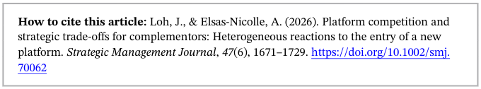

NOTE: figure/graphic rendered as an image from the PDF; its content is not machine-readable text. Caption (if any) follows as the next block.

**text found inside the figure**

How to cite this article: Loh, J., & Elsas-Nicolle, A. (2026). Platform competition and strategic trade-offs for complementors: Heterogeneous reactions to the entry of a new platform. Strategic Management Journal, 47(6), 1671–1729. https://doi.org/10.1002/smj. 70062

APPENDIX A: ADDITIONAL ANALYSES ON THE MULTIHOMING DECISION

This appendix presents additional descriptive statistics and regression results that both demonstrate the robustness of our main findings and provide further insights into the mechanisms driving complementors’ multihoming decisions.

A.1 | Additional descriptive statistics: Timing of multihoming

Our multihoming analysis is based on a cross-section of games for which we construct a binary indicator: it takes the value one if a game appears in both catalogs (Steam and Epic) at the end of the observation period, and zero otherwise. For a subsample of games, we observe the exact release dates—on Steam for singlehoming games and on both platforms for multihoming games. For this subsample, we compute the number of weeks between the two release dates (if multihoming occurs). We use this duration as an alternative dependent variable to assess how our key characteristics influence the timing of multihoming, including both games that multihome and those that remain exclusive to one platform.

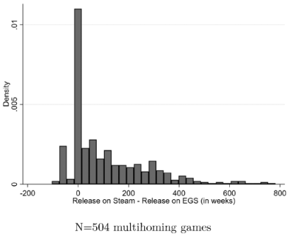

NOTE: figure/graphic rendered as an image from the PDF; its content is not machine-readable text. Caption (if any) follows as the next block.

FIGURE A1 Histogram of the time before multihoming (only multihoming games). N = 504 multihoming games.

Among the 504 multihoming games in our sample for which precise release dates are available, 63% were first released on Steam and later became available on EGS, 27% were released simultaneously on both platforms, and approximately 9.5% appeared on EGS before Steam. To our knowledge, only three games fully migrated from Steam to EGS.

Figure A1 presents a histogram of the time interval before multihoming. Negative values indicate that a game was first released on EGS and only later on Steam. Table A1 provides broader descriptive statistics, including games that never multihomed. To assess the impact of the rival platform's entry on multihoming decisions, we restrict the sample to games that were already available on Steam before the entry and compute the number of weeks they remained exclusive before joining the entrant. While the resulting sample is relatively small (172 games), it still offers insight into how long it typically took for these games to multihome. Figure A2 presents a histogram of this duration.

A.2 | Additional analysis: Timing of multihoming

As mentioned in Appendix A (Additional descriptive statistics: Timing of multihoming), for most games in our main sample, we can compute the number of weeks before multihoming

TABLE A1 Timing of multihoming.

|  | Freq. | Percent | Cum. |
| --- | --- | --- | --- |
| OnlySteam(nomultihoming) | 7522 | 9372 . | 9372 . |
| SteamandthenEGS | 319 | 397 . | 9769 . |
| Simultaneousrelease | 137 | 171 . | 9940 . |
| EGSandthenSteam | 48 | 060 . | 100 |
| Total | 8026 | 10000 . | 100 |

NOTE: table converted from PDF layout to HTML text; cell boundaries are reconstructed. See PDF if exact alignment matters.

Note: The full sample includes 8101 games. The analyses presented here are based on a subsample of 8026 games, as some were excluded due to missing exact release dates at the weekly level. Among these, 504 games are classified as multihoming.

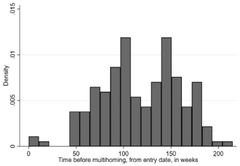

NOTE: figure/graphic rendered as an image from the PDF; its content is not machine-readable text. Caption (if any) follows as the next block.

FIGURE A2 Histogram of duration post entry (time from event).

TABLE A2 Estimation results for our survival analyses.

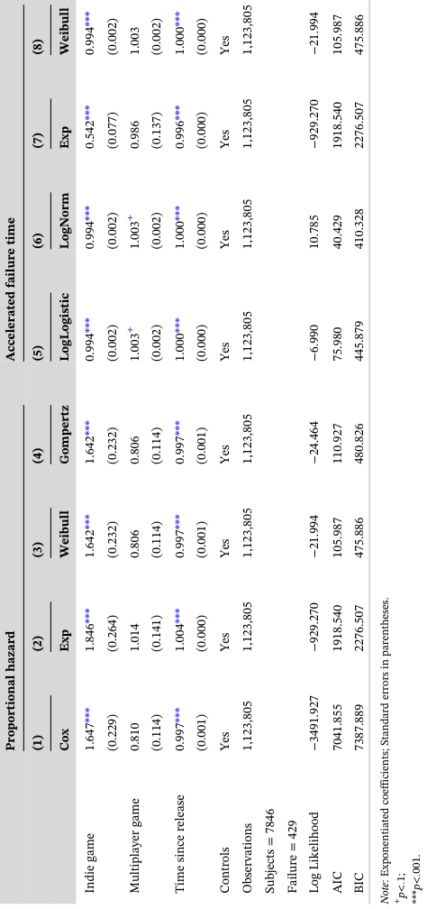

NOTE: complex table shown as an image of the PDF; the text below is a rough machine extraction and may be mis-aligned.

**extracted text (unreliable layout)**

occurs—if it occurs. This censored duration, illustrated in Figure A1, serves as the dependent variable in additional analyses. The aim is to estimate the influence of our key characteristics (Indie and multiplayer) on the likelihood and timing of multihoming, including both games that eventually multihome and those that remain exclusive. This approach allows us to incorporate some dynamic aspects into the analysis.

From this sample, we construct a panel dataset that begins with the entry of EGS in December 2018. Games remain in the panel until they multihome, resulting in repeated observations with both time-varying and time-invariant controls. The final panel comprises 1,123,805 weekly observations, with 429 events (i.e., games multihoming) observed. We estimate a set of proportional hazard (PH) and accelerated failure-time (AFT) models. These models enable us to assess the effect of our two key variables of interest—Indie and multiplayer—on the time to multihoming and the likelihood of remaining exclusive (i.e., survival without multihoming).

We present our estimation results in Table A2. In the Proportional Hazard (PH) models, a coefficient greater than 1 implies that an increase in the corresponding regressor raises the hazard rate, that is, increases the likelihood of multihoming. In contrast, the interpretation is reversed in Accelerated Failure Time (AFT) models: coefficients above 1 indicate a longer expected survival time—in our context, a lower likelihood or slower timing of multihoming. The results are broadly consistent across model specifications, although some differences in sign and significance levels appear. To assess model suitability, we first perform a Schoenfeld residuals test, which rejects the proportional hazards assumption. We therefore place greater emphasis on the AFT models. Among these, the specification using a log-normal hazard distribution (Column 6) provides the best fit based on the AIC criterion. Focusing on this preferred specification, we find that the exponentiated coefficient for the Indie indicator is 0.994 (p < .001), indicating that Indie games are more likely to multihome and tend to do so sooner, supporting Hypothesis 1a. The exponentiated coefficient for the Multiplayer indicator is 1.003 and significant at the 10% level, suggesting that multiplayer games are slightly less likely to multihome and multihome at a slower rate, supporting Hypothesis 2a. Overall, the survival analysis provides further support for both Hypotheses 1a and 2a, reinforcing our interpretation of complementor behavior in response to the platform's entry.

A.3 | Additional analysis: Games released before and after the EGS launch

Using our main specification, we explore some of the underlying mechanisms by splitting the sample into games released before and after the launch of EGS. This distinction is potentially meaningful: games released before EGS had the opportunity to generate sales on Steam and may have become subject to lock-in effects. For these games, multihoming implies splitting an existing player base and potentially incurring switching costs. In contrast, games released after

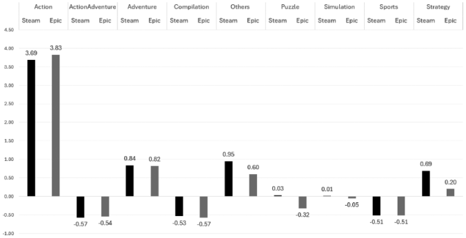

NOTE: figure/graphic rendered as an image from the PDF; its content is not machine-readable text. Caption (if any) follows as the next block.

TABLE A3 Multihoming analysis: Before and after EGS's launch.

|  | After | Before |  |
| --- | --- | --- | --- |
|  | (1) | (2) | (3) |
| Hypothesis1a:Indiegame | 00360** . | 00297*** . | 00281** . |
|  | (00122) . | (00089) . | (00089) . |
| Hypothesis2a:Multiplayergame | 00036 − . | 00141 − . | 00141 − . |
|  | (00116) . | (00088) . | (00089) . |
| Pre-EGS review count (1000s) |  |  | 00004* . |
|  |  |  | (00002) . |
| Pre-EGS positive review share |  |  | 01089*** . |
|  |  |  | (00290) . |
| Genredummies | Y | Y | Y |
| Releaseyeardummies | Y | Y | Y |
| Controls | Y | Y | Y |
| Observations | 3612 | 4275 | 4236 |
| MeanDV | 00927 . | 00550 . | 00552 . |
| Pseudo-R2 | 0271 . | 0211 . | 0221 . |

NOTE: table converted from PDF layout to HTML text; cell boundaries are reconstructed. See PDF if exact alignment matters.

Note: Robust standard errors in parentheses. The unit of observation is a game. The dependent variable is a dummy indicating if the game multihomes at the end of our observation period. All models are estimated using logit specifications, and average marginal effects are reported. Model 1 uses a sample of games released after EGS's launch. Models 2 and 3 use a sample of games released before. ***p < .001; **p < .01; *p < .5;

EGS's launch face no such legacy constraints and can choose from the outset whether to join one or both platforms.

A.4 | Additional analysis: Pre-EGS quality and popularity of games

We further examine the role of game popularity and quality in shaping complementors’ decisions to multihome. Focusing again on the subsample of games released before the EGS launch, we investigate how two measures of market performance on Steam—the number of reviews and the share of positive reviews—relate to the multihoming decision, and how these relationships vary across different types of games. To this end, Table A4 presents results from a series of sample splits: between Indie and non-Indie games (Models 1 and 2), and between multiplayer and singleplayer games (Models 3 and 4). Across nearly all specifications, we find that a higher share of positive reviews is associated with a greater likelihood of multihoming. This suggests that developers are more inclined to make higher-quality games available on EGS, presumably

TABLE A4 Multihoming analysis: Pre-EGS quality and performance of games.

|  | Indiegame |  | Multiplayer |  |
| --- | --- | --- | --- | --- |
|  | Yes | No | Yes | No |
|  | (1) | (2) | (3) | (4) |
| Pre-EGS review count (1000s) | 00011** . | 00004 . | 00004 . | 00010 . |
|  | (00004) . | (00002) . | (00003) . | (00007) . |
| Pre-EGS positive review share | 01295** . | 00818* . | 00867+ . | 01218** . |
|  | (00489) . | (00398) . | (00512) . | (00373) . |
| Genredummies | Y | Y | Y | Y |
| Releaseyeardummies | Y | Y | Y | Y |
| Controls | Y | Y | Y | Y |
| Observations | 2321 | 1887 | 1264 | 2847 |
| MeanDV | 00517 . | 00604 . | 00649 . | 00534 . |
| Pseudo-R2 | 0289 . | 0235 . | 0218 . | 0274 . |

NOTE: table converted from PDF layout to HTML text; cell boundaries are reconstructed. See PDF if exact alignment matters.

Note: Robust standard errors in parentheses. The unit of observation is a game. The dependent variable is a dummy indicating whether the game multihomes at the end of our observation period. All models are estimated using logit specifications, and average marginal effects are reported. All models use a sample of games released before EGS's launch. **p < .01; *p < .5; <sup>+</sup>p < .1.

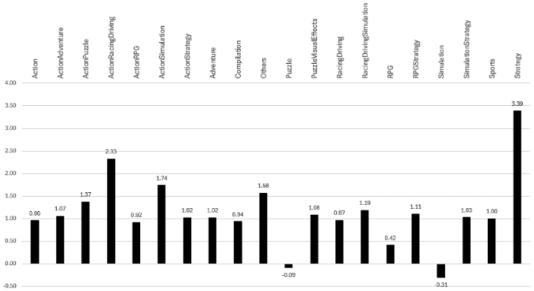

NOTE: figure/graphic rendered as an image from the PDF; its content is not machine-readable text. Caption (if any) follows as the next block.

expecting to generate additional revenue from the new platform. In contrast, the review count—which we interpret as a proxy for prior sales—exhibits a more nuanced pattern. We find a positive association only for Indie games. This aligns with our theoretical expectations: Indie developers, facing more intense competition on Steam, are more likely to perceive EGS as an attractive outside option. They multihome with their higher-demand titles to exploit new revenue opportunities. For multiplayer games, however, we do not observe a similar pattern. This is consistent with our theoretical framework: The types of complementors that are most likely to multihome are even more likely to do so with their most popular and well-received titles, which likely promise the highest marginal returns from expanding market access over multiple platforms.

A.5 | Additional analysis: Interaction between games characteristics

Table A5 explores whether developers’ decisions to multihome depend not only on individual game characteristics, but also on their interaction. In Column 2, we introduce interaction terms to capture how the combination of being an indie and a multiplayer game may jointly influence multihoming behavior. Results from the interaction model suggest a nuanced pattern: the effect of being an indie game remains strongly positive and significant when the game is not multiplayer, but the combination of indie and multiplayer characteristics yields a smaller and statistically insignificant effect. This suggests that the positive association between the indie characteristics and multihoming is “attenuated” when the game also offers multiplayer features.

FIGURE A4 Ratio of Z-scores. Values are averaged over the full observation period.

A.6 | Additional analysis: Interdependence of decisions—does sales participation determine multihoming?

We examine whether the two strategic choices under study—multihoming and participation in sales promotions—are interdependent. We test whether complementors that participate in more sales are also more likely to multihome. To do so, we restrict the analysis to the sample of games used in the sales participation analysis, that is, those that were already active on Steam prior to EGS's launch. Model 1 in Table A6 reports results for this restricted sample and confirms the robustness of our main findings. In Model 2, we include a variable capturing the total number of sales in which a game has participated. The coefficient is not statistically significant, suggesting no clear relationship. In Model 3, we differentiate between sales participation before and after the launch of EGS to allow for potential dynamics. Again, both coefficients are statistically insignificant. Taken together, these results do not support the notion that sales participation and multihoming are interdependent strategic choices.

TABLE A5 Multihoming analysis: Indie-multiplayer interaction.

|  | (1) | (2) |
| --- | --- | --- |
|  | Baselinemodel | Modelwithinteractions |
| Indiegame | 00298*** . |  |
|  | (00072) . |  |
| Multiplayergame | 00112 − . |  |
| Indie =0 ^ MP =0 | (00072) . | Baseline |
| Indie =0 ^ MP =1 |  | 00014 − . |
|  |  | (00103) . |
| Indie =1 ^ MP =0 |  | 00350*** . |
|  |  | (00080) . |
| Indie =1 ^ MP =1 |  | 00151 . |
|  |  | (00109) . |
| Observations | 8101 | 8101 |

NOTE: table converted from PDF layout to HTML text; cell boundaries are reconstructed. See PDF if exact alignment matters.

Note: Marginal effects are reported. Robust standard errors in parentheses. ***p<:001.

A.7 | Additional analysis: Multihoming and within-genre competition

This set of analyses aims to assess how the relative attractiveness of platforms—particularly in terms of within-genre competitive intensity—affects the likelihood that complementors choose to multihome. To conduct this exercise, we construct a monthly-level catalog of games on each platform (Steam and Epic), and for each genre, we compute the number of complements offered. We have to drop games for which we do not have information about the month of release. Additionally, to ensure consistent classification of games, we rely on the genre indicated on Moby Games, rather than the genre declared on each platform. We obtained, in total, 8889 games on Steam and 660 games on Epic over the period. Given the variety of genres and combination of genres, we keep the 20 main genres (which represent about 88% of games) and group the remaining genres in the “Other” genre group.

We compute, for each platform p, genre g, and month t, the number of games active on the platform and denote it Gamespgt. This captures the level of within-platform competition in each genre over time. To compare competition intensity across platforms and genres, we then compute a standardized score (Z-score) for each Gamespgt, which reflects how a given genre is positioned relative to the distribution of all genres on the same platform. This allows us to assess whether a particular genre is relatively crowded (or sparse) on a given platform at a given point

in time. This score is computed as follows: Zpgt = <sup>Games</sup><sup>pgt</sup><sup>−</sup><sup>Games</sup><sup>pt</sup>

SD Gamespt ð Þ . Figure A3 displays the Z-scores

for selected genres across both platforms, aggregated over the entire observation period.

A Z-score of 3, for example, indicates that the genre is significantly more populated than the average genre on that platform, suggesting a high level of within-platform competition.

TABLE A6 Multihoming analysis: With sales participation.

|  | (1) | (2) | (3) |
| --- | --- | --- | --- |
| Indiegame | 00282** . | 00277** . | 00281** . |
|  | (00100) . | (00099) . | (00099) . |
| Multiplayergame | 00141 − . | 00141 − . | −0 .0145 |
|  | (00097) . | (00097) . | (00096) . |
| Shareofsalesthegameparticipatedin |  | 00002 . |  |
| Shareofsalesthegameparticipatedin(BeforeEntry) |  | (00003) . | 00002 − . |
|  |  |  | (00003) . |
| Shareofsalesthegameparticipatedin(AfterEntry) |  |  | 00004 . |
|  |  |  | (00003) . |
| Controls | Yes | Yes | Yes |
| Observations | 3496 | 3496 | 3496 |

NOTE: table converted from PDF layout to HTML text; cell boundaries are reconstructed. See PDF if exact alignment matters.

Note: Marginal effects are reported. Robust standard errors in parentheses. This analysis uses the sample of games included in our sales participation analyses (4191 games). Due to missing data on some variables, the effective sample consists of 3496 unique games. Column 1 reports estimates from our main specification using this restricted sample. Column 2 adds a variable capturing the share of sales a game participated in during the period from December 2017 to December 2019. Column 3 separates this measure into participation shares before and after the launch of the Epic Games Store. **p<:01;

Conversely, a negative Z-score implies that the genre is less populated than average, reflecting lower competition. Figure A3.

Figure A4 illustrates how this measure varies across genres. We include Ratiog as an additional regressor in our multihoming regressions to account for the relative attractiveness of genre-level competition across platforms.

Table A7 presents results from our most complete specification. The coefficient on Ratiog is statistically insignificant, suggesting that relative genre-level competition across platforms does

TABLE A7 Multihoming analysis: With relative attractiveness measures.

|  | (1) | (2) | (3) | (4) | (5) | (6) | (7) |
| --- | --- | --- | --- | --- | --- | --- | --- |
|  |  | Withrelativeattractivenessmeasures |  |  |  |  |  |
|  |  | Zscores |  | Counts |  | Shares |  |
|  |  | w/ |  | w/ |  | w/ |  |
|  | Main | genre | w/o | genre | w/o | genre | w/o |
|  | model | FEs | genreFEs | FEs | genreFEs | FEs | genreFEs |
| Indiegame | 00298*** . | 00320*** . | 00298*** . | 00324*** . | 00300*** . | 00321*** . | 00299*** . |
|  | (00072) . | (00072) . | (00072) . | (00072) . | (00072) . | (00072) . | (00072) . |
| Multiplayer | 00112 − . | −0 .0159* | 00111 − . | 00163* − . | 00116 − . | 00160* − . | 00113 − . |
| game | (00072) . | (00064) . | (00072) . | (00064) . | (00072) . | (00064) . | (00072) . |
| Ratiog (Z |  | 00003 − . | 00027 . |  |  |  |  |
| scores) |  | (00041) . | (00042) . |  |  |  |  |
| Ratiog |  |  |  | 00003+ . | 00002 . |  |  |
| (counts) |  |  |  | (00002) . | (00002) . |  |  |
| Ratiog |  |  |  |  |  | 00037 . | 00029 . |
| (shares) |  |  |  |  |  | (00068) . | (00074) . |
| Controls | Yes | Yes | Yes except , | Yes | Yes except , | Yes | Yes except , |
|  |  |  | GenreFES |  | GenreFES |  | GenreFES |
| Observations | 8101 | 8101 | 8101 | 8101 | 8101 | 8101 | 8101 |

NOTE: table converted from PDF layout to HTML text; cell boundaries are reconstructed. See PDF if exact alignment matters.

Note: Marginal effects are reported. Robust standard errors in parentheses. +p<:10; *p<:05; ***p<:001.

not meaningfully affect the multihoming decision. Given the limited variation in this measure across platforms and genres, this result is perhaps not surprising. As a robustness check, Columns 4 to 7 replicate the analysis using two alternative measures of relative competition: (i) the raw ratio of absolute counts of games per genre, and (ii) a share-based measure. Results are consistent with those relying on the Z-scores, suggesting that our conclusions do not depend on the specific scaling choice. However, these alternative metrics are sensitive to large differences in platform size. For this reason, the Z-score approach remains the most appropriate metric for capturing relative within-platform competition, while enabling meaningful cross-platform comparisons.

A.8 | Robustness check: Coarsened exact matching

We re-estimate our models using matched samples. Instead of including linear control variables, we use them to construct matched samples for each “treatment” indicator. Specifically, we match Indie games to comparable non-Indie games and multiplayer games to comparable singleplayer games. The results are presented in Table A8. As it is not possible to match on multiple treatment indicators simultaneously within the same regression, we analyze each game type separately. The findings are consistent with our main results.

TABLE A8 Multihoming analysis: Coarsened exact matching.

|  | CEM |  |
| --- | --- | --- |
|  | (1) | (2) |
| Hypothesis1a:Indiegame | 00294** . |  |
| Hypothesis2a:Multiplayergame | (00092) . | −0 .0159 |
|  |  | (00126) . |
| Genredummies | Y | Y |
| Releaseyeardummies | Y | Y |
| Observations | 4019 | 4182 |
| MeanDV | 00488 . | 00493 . |
| Pseudo-R2 | 0079 . | 0060 . |

NOTE: table converted from PDF layout to HTML text; cell boundaries are reconstructed. See PDF if exact alignment matters.

Note: Robust standard errors in parentheses. The unit of observation is a game. The dependent variable is a dummy indicating whether the game multihomes at the end of our observation period. All models are estimated using logit specifications, and average marginal effects are reported. All models use the matched samples of games (CEM). **p < .01;

A.9 | Robustness check: Intensity of multihoming at the publisher level

For each publisher, we calculate a multihoming intensity measure defined as the share of their games available on both platforms, as of June 2022. This measure ranges from 0 (none of the publisher's games multihome) to 1 (all games multihome). We then regress this intensity on the average characteristics of the games in each publisher's portfolio—specifically, the share of Indie games and the share of multiplayer games—alongside controls such as the total number of games in the portfolio and variables from our main model. Due to missing values on some controls (in particular for development team size), the effective sample size is reduced to 1568 publishers. On average, 69% of games in a publisher's portfolio are Indie, and 35% are multiplayer.

Table A9 presents the results from OLS regressions. Column 1 uses the full sample; Columns 2 and 3 restrict the sample to publishers with more than one and more than five games, respectively. While the results broadly align with our game-level findings—the positive impact

TABLE A9 Estimation results for the intensity of multihoming.

|  | Intensityofmultihoming |  |  |  |  |
| --- | --- | --- | --- | --- | --- |
|  | DV=shareofgamesonbothplatforms |  |  |  |  |
|  | (1) | (2) |  | (3) |  |
|  |  | Publisherswith |  | Publisherswith |  |
|  | Allpublishers | >1game |  | >5games |  |
| Shareofindiegames | 0031** (0011) . . | 0066* . | (0027) . | 0025 . | (0050) . |
| Shareofmultiplayergames | 0003 (0013) − . . | 0031 − . | (0035) . | 0121 . | (0082) . |
| Totalnumberofgamesinpublisher'sportfolio | 0002* (0001) . . | 0000 . | (0001) . | 0001 . | (0002) . |
| Averagereleaseyear | 0006*** (0002) . . | 0004 . | (0005) . | 0019* . | (0007) . |
| Averagenumberofreviews | 0000** (0000) . . | 0000* . | (0000) . | 0000 . | (0000) . |
| Averageofshareofpositivereviews | 0026 (0024) . . | 0002 . | (0050) . | 0203 . | (0128) . |
| Averagenumberofdevelopers | 0000 (0000) . . | 0000 . | (0000) . | 0000 . | (0000) . |
| Averageprice | 0002*** (0001) . . | 0002* . | (0001) . | 0002 − . | (0002) . |
| Averagenumberofplayers | 0000 (0000) − . . | 0000+ − . | (0000) . | 0000 − . | (0000) . |
| ShareofUnrealEnginegames | 0057 (0041) . . | 0086 . | (0072) . | 0080 . | (0124) . |
| Othercontrols | Yes | Yes |  | Yes |  |
| Observations(publishers) | 1568 | 560 |  | 132 |  |
| R2 | 0117 . | 0157 . |  | 0465 . |  |

NOTE: table converted from PDF layout to HTML text; cell boundaries are reconstructed. See PDF if exact alignment matters.

Note: Robust standard errors in parentheses. The dependent variable is a continuous measure of the intensity of multihoming (total number of multihoming games divided by total number of games) at the publisher level, as of June 2022. The intensity measure ranges between 0 and 1. All regressors are computed as portfolio-level averages across a publisher's games. +p<:1; *p<:05; **p<:01; ***p<:001.

of the share of Indie games on multihoming intensity—we do not find a significant effect for the share of multiplayer games. Given the reduced sample sizes and the aggregation of information at the publisher level, we believe these results should be interpreted with caution.

APPENDIX B: ADDITIONAL ANALYSES ON SALES PARTICIPATIONS

This appendix presents additional descriptive statistics and estimation results that further support the robustness of our main findings and provide additional insights into their underlying mechanisms.

B.1 | Additional descriptive statistics: Sales

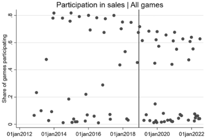

NOTE: figure/graphic rendered as an image from the PDF; its content is not machine-readable text. Caption (if any) follows as the next block.

FIGURE B1 Participation in sales, over time. The vertical line indicates the entry of EGS. Each bullet represents a sale event on Steam at a given point in time. Some sales are particularly popular, with up to 80% of the games in our sample participating, while others are more limited in scope. The main results presented in the paper are based on a subsample of these sales, that is, those that occurred within the 12 months before and after the entry of EGS.

TABLE B1 Descriptive statistics on Steam sales included in our analysis period.

|  |  |  | Main |
| --- | --- | --- | --- |
| Sale | Startingcalendarweek | Participationshare | sample |
| FinlandAnniversarySale2017 | 2017-49 | 098% . |  |
| WinterSale2017 | 2017-51 | 7517% . | Yes |
| LunarNewYearSale2018 | 2018 -07 | 5339% . | Yes |
| GDCFilmFestivalSale2018 | 201812 - | 393% . | Yes |
| VRSpringSale2018 | 201816 - | 300% . | Yes |
| GamesfromDenmarkSale2018 | 2018 -17 | 057% . |  |
| SpringCleaningEvent2018 | 201821 - | 058% . |  |

NOTE: table converted from PDF layout to HTML text; cell boundaries are reconstructed. See PDF if exact alignment matters.

B.2 | Pre-trends in sales participation

Our sales analyses follow an event-study design that exploits variation before and after a shock (i.e., the entry of EGS). Our outcome of interest (complementors’ participation in sales) exhibits a particularly erratic evolution across time periods, with sales being very popular and others

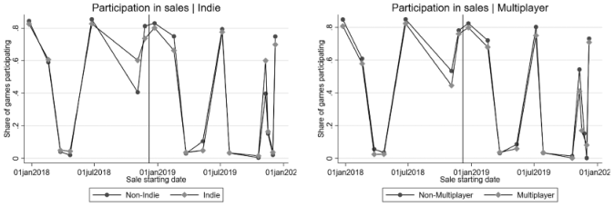

NOTE: figure/graphic rendered as an image from the PDF; its content is not machine-readable text. Caption (if any) follows as the next block.

FIGURE B2 Average sales participation, by groups of interest.

TABLE B1 (Continued)

|  |  |  | Main |
| --- | --- | --- | --- |
| Sale | Startingcalendarweek | Participationshare | sample |
| SummerSale2018 | 2018 -25 | 7491% . | Yes |
| DayoftheGirlSale2018 | 201841 - | 074% . |  |
| HalloweenSale2018 | 201844 - | 4536% . | Yes |
| YearsofPolishIndependenceSale2018 | 2018 -45 | 013% . |  |
| GamesfromNorwaySale2018 | 201846 - | 042% . |  |
| AutumnSale2018 | 2018 -47 | 6748% . | Yes |
| WinterSale2018 | 2018 -51 | 7178% . | Yes |
| LunarNewYearSale2019 | 201906 - | 6150% . | Yes |
| SXSWTexasSale2019 | 201911 - | 285% . | Yes |
| BAFTASale2019 | 201914 - | 094% . |  |
| GoldenWeekSale2019 | 201918 - | 698% . | Yes |
| SpringCleaningEvent2019 | 201921 - | 058% . |  |
| WorldEnvironmentDaySale2019 | 201923 - | 067% . |  |
| SummerSale2019 | 201926 - | 6843% . | Yes |
| SpaceExplorationSale2019 | 201929 - | 268% . | Yes |
| LGBTQ+GamesSale | 201941 - | 120% . | Yes |
| HalloweenSale2019 | 201944 - | 4483% . | Yes |
| Singles’DaySale | 2019 -45 | 1476% . | Yes |
| RemotePlayTogether2019 | 2019 -47 | 252% . | Yes |
| AutumnSale2019 | 201948 - | 6211% . | Yes |

NOTE: table converted from PDF layout to HTML text; cell boundaries are reconstructed. See PDF if exact alignment matters.

much more confidential, as shown in Figure B1. Such a setting does not allow for a nice, “visual” approach. However, in this section, we aim to provide evidence that the complementor groups we study did not differ significantly before the shock. To do so, we will proceed in two steps. First, we compute average participation, at the sale level, for each group of complementors and present these results in Figure B2. To ease readability, we present, within this figure, a sub-figure for each group of interest. We observe that the groups have similar participation levels before the entry.

However, as these unconditional averages may not account for relevant factors, we complement the analysis with a regression-based approach. As a second step, we estimate a model structurally equivalent to our main sales regressions but restricted to the pre-shock period. In this setting, the complementor-type indicators (Indie and multiplayer) enter the model without interaction terms, as there is no post-period. Because game fixed effects are collinear with these time-invariant indicators, we instead control for all variables used in our multihoming regressions, including both time-varying and invariant covariates. We further include sale fixed effects to capture time-specific shocks. Figure B3 presents the resulting coefficients. The lack of statistically significant differences supports our identification strategy by indicating that our groups of interest did not differ systematically in their sales participation before the shock.

TABLE B2 Sales participation analysis: Difference in means before and after matching.

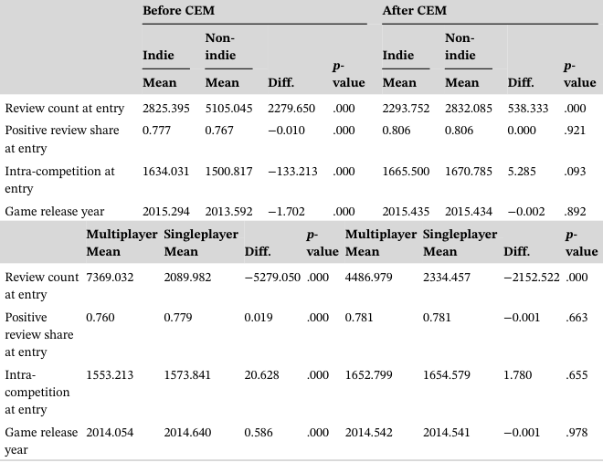

NOTE: complex table shown as an image of the PDF; the text below is a rough machine extraction and may be mis-aligned.

**extracted text (unreliable layout)**

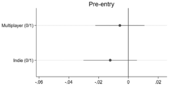

NOTE: figure/graphic rendered as an image from the PDF; its content is not machine-readable text. Caption (if any) follows as the next block.

B.3 | Matching procedure: Differences in means

We assess the effectiveness of our matching strategy by testing for differences in means across the matching variables before and after matching. Specifically, we examine whether observable differences between complementor types—Indie vs. non-Indie and multiplayer vs. singleplayer—are reduced following coarsened exact matching. Table B2 below reports the results. Prior to matching, we observe clear and statistically significant differences in all matching variables for both comparisons. After matching, these differences largely disappear, indicating improved balance of covariates. The one exception is the pre-EGS review count, which remains statistically significant in both comparisons, though the magnitude of the differences is substantially reduced. This suggests that the comparability between complementor

FIGURE B3 Estimation results for our sales analysis (only pre-period). Coefficients are estimated from a regression that includes sale fixed effects and all game-level controls. 95% confidence intervals are shown. The sample includes 3680 games and 25,701 observations (pre-shock periods only).

TABLE B3 Sales participation analysis: Major vs. minor sales.

|  | Majorsale | Minorsale | Majorsale | Minorsale |
| --- | --- | --- | --- | --- |
|  | (1) | (2) | (3) | (4) |
| After × Indiegame | 0010 − . | −0 .027*** |  |  |
| After × MPgame | (0009) . | (0008) . | 0010 − . | 0030*** . |
|  |  |  | (0009) . | (0007) . |
| GameFE | Y | Y | Y | Y |
| SteamsaleFE | Y | Y | Y | Y |
| Observations | 30210 , | 24168 , | 30730 , | 24584 , |
| Games | 3021 | 3021 | 3073 | 3073 |
| MeanDV | 0673 . | 00534 . | 0667 . | 00527 . |
| Adjusted R -squared | 05478 . | 00542 . | 05301 . | 00588 . |
| Within-R2 | 6 .92e−05 | 0000755 . | 6 .39e−05 | 0000971 . |

NOTE: table converted from PDF layout to HTML text; cell boundaries are reconstructed. See PDF if exact alignment matters.

Note: Robust standard errors in parentheses are clustered at the game level. The unit of observation is a game-sale. The dependent variable is a dummy indicating whether the game participated in a sale. All estimations use linear probability models and include game and sale fixed effects. All models use a sample of matched games (CEM). A constant is included but not reported. ***p < .001;

types improves meaningfully after matching. Furthermore, our main results remain robust when we include the matching variables as linear controls in the regression, in addition to matching on their pre-EGS values.

B.4 | Additional analysis: Minor versus major sales

In this additional analysis, we explore potential heterogeneity in complementors’ responses across different types of sales. As pointed out earlier, and shown in Table B1, sales events vary considerably in their popularity—some, such as the Winter Sales, attract broad participation, while others are more niche and appeal to specific game types. We, therefore, re-estimate our main models using a split sample approach. We classify a sale as major if at least 40% of games in our sample participate, and as minor otherwise. We use matched samples for these estimations (as in Models 5–7 of Table 4). We find that the responses to EGS's launch seem to be entirely driven by minor sales: Indie games become significantly less likely to participate in minor sales after the entry, while multiplayer games are significantly more likely to do so. For major sales, we observe no significant changes for either group. These results add nuance to the overall picture: evidently, game developers are not willing to forego the high-demand periods generated by major sales. Instead, they react in terms of their responsiveness to more targeted promotional events. This also puts into perspective our prior assessment of the economic significance of the effects. The average game participates in only around 5%–6% of minor sales. As a result, the estimated coefficients for Indie (Model 2, β= −0:027) and multiplayer games (Model 4, β=0:030) imply large economic effect sizes (Table B3).

B.5 | Additional analysis: Discounts outside sales

We analyze how EGS's launch affected complementors’ tendency to offer their product at a discount outside Steam's sale promotions. Part of the aim of our study is to show how increased platform competition impacts their responsiveness to orchestration attempts. However, it is possible that complementors generally have less of an incentive to discount their product, which could then offer an alternative explanation for our results. However, if this is the case, then we would also observe a change in their tendency to do so outside Steam sales. To test this, we estimate a series of regressions using a game-week panel that excludes weeks with an active Steam sale. As in our main analysis, we use models with time-varying controls as well as matched samples. Results are presented in Table B4. Across all models, we find no significant effect of EGS's launch on the likelihood of games being discounted outside of promotional periods. We interpret this as evidence that complementors are indeed responding specifically to platform orchestration efforts rather than changing their overall discounting behavior.

B.6 | Additional analysis: Interaction between games characteristics

Complementor types are not mutually exclusive. For example, an Indie game may include multiplayer functionality. To further explore how these two dimensions interact and which of the opposing effects dominates, we conduct an additional set of regressions. We define four groups

of games based on the combination of our two main treatment indicators: (i) non-Indie and singleplayer (Indie =0 ^ MP =0), (ii) Indie and singleplayer (Indie =1 ^ MP =0), (iii) non-Indie and multiplayer (Indie =0 ^ MP =1), and (iv) Indie and multiplayer (Indie =1 ^ MP =1). We then interact dummy variables for each of these groups with a dummy indicating sales taking place after EGS's launch. As before, we include the full set of control variables and fixed effects. Results are presented in Table B5. Model 1 is run on the full sample of games. The group of “non-Indie-and-singleplayer” games serves as the baseline group. We find that “Indie-andsingleplayer” games are less likely to participate in sales after EGS's launch compared to the baseline (β= −0:0102). However, the coefficient is estimated with limited precision (p<0:1). In addition, “Non-Indie-and-multiplayer” games are more likely to (β=0:0264, p<0:001). Both are consistent with Hypotheses 1b and 2b. For the group of “Indie-and-multiplayer” games, we do not find a significant difference compared to the baseline. This may indicate that the two opposing effects cancel each other out for this group.

To validate these results, we re-estimate the model on a sample of similar games. Because coarsened exact matching (CEM) cannot accommodate multiple treatment groups simultaneously, we use an unweighted sample of games for which at least one comparable match exists along our matching variables. This approach reduces the sample to approximately one-third of the original size. As shown in Model 2, the estimated coefficients are similar in direction to those in Model 1, though less precise. For instance, the effect for “Indie- singleplayer” games becomes statistically insignificant. Nonetheless, the overall pattern of results reinforces our theoretical predictions: complementors’ responses to the entry of a rival platform depend on the interplay between their resource endowment and their reliance on network effects.

TABLE B4 Sales participation analysis: Discounts outside sale periods.

|  | Fullsample |  |  | CEM |  |
| --- | --- | --- | --- | --- | --- |
|  | (1) | (2) | (3) | (4) | (5) |
| After × Indiegame | 00030 − . |  | 00033 − . | 00015 . |  |
|  | (00036) . |  | (00036) . | (00052) . |  |
| After × MPgame |  | 00001 − . | 00002 − . |  | 00038 − . |
|  |  | (00039) . | (00039) . |  | (00062) . |
| GameFE | Y | Y | Y | Y | Y |
| Year-Week FE | Y | Y | Y | Y | Y |
| Controls | Y | Y | Y |  |  |
| Observations | 296696 , | 296696 , | 296696 , | 205078 , | 195681 , |
| Games | 3860 | 3860 | 3860 | 2668 | 2546 |
| MeanDV | 0129 . | 0129 . | 0129 . | 0132 . | 0132 . |
| Adjusted R -squared | 03529 . | 03529 . | 03529 . | 03425 . | 03488 . |
| Within-R2 | 00000336 . | 00000259 . | 00000427 . | 0000106 . | 00000526 . |

NOTE: table converted from PDF layout to HTML text; cell boundaries are reconstructed. See PDF if exact alignment matters.

B.7 | Additional analysis: Interdependence between decisions—Does multihoming determine sales participation?

It is possible that the decisions to multihome and to continue participating in Steam sales are interdependent. We already explore this question to some extent in Appendix A (Additional analysis: Interdependence of decisions—Does sales participation determine multihoming?), where we re-estimate part of our multihoming analyses including the intensity of sales participation as an additional regressor. There, we find no significant effect. In this section, we investigate the reverse relationship: whether participation in sales is influenced by the decision to multihome. Indeed, multihoming games may be more or less likely to adjust their responsiveness to the incumbent's orchestration attempts. To test this possibility, we run an additional set of regressions in which we let the probability of sales participation vary between games that multihome and those that do not. We further analyze how this relationship differs across complementor types.

Instrumental variable approach: Estimating the influence of multihoming presents an endogeneity concern. Since both homing decision and sales participation can be seen as manifestations of a complementor's ongoing engagement with (or support for) the incumbent platform, the error term in a regression of sales participation is likely correlated with the multihoming indicator. To address this issue, we use an instrumental variables approach. Specifically, we instrument the multihoming indicator (the endogenous regressor here) with a dummy

TABLE B5 Sales participation analysis: Indie-multiplayer interaction.

|  | (1) | (2) |
| --- | --- | --- |
|  | Fullsample | Matchedsample |
| After × 1ðIndie =0 ^ MP =0Þ | Baseline | Baseline |
| After × 1ðIndie =1 ^ MP =0Þ | 00102+ − . | 00139 − . |
|  | (00061) . | (00120) . |
| After × 1ðIndie =0 ^ MP =1Þ | 00264*** . | 00338* . |
|  | (00064) . | (00134) . |
| After × 1ðIndie =1 ^ MP =1Þ | 00122 . | 00045 . |
|  | (00077) . | (00132) . |
| GameFE | Y | Y |
| SteamsaleFE | Y | Y |
| Controls | Y |  |
| Observations | 75179 , | 24138 , |
| Games | 4191 | 1341 |
| MeanDV | 0384 . | 0399 . |
| Adjusted R -squared | 05769 . | 05675 . |
| Within-R2 | 0000915 . | 0000708 . |

NOTE: table converted from PDF layout to HTML text; cell boundaries are reconstructed. See PDF if exact alignment matters.

Note: Robust standard errors in parentheses are clustered at the game level. The unit of observation is a game-sale. The dependent variable is a dummy indicating whether the game participated in a sale. All estimations use linear probability models and include game and sale fixed effects. Model 1 uses the full sample. Model 2 is estimated on a sample of games matched via coarsened exact matching (CEM). A constant is included but not reported. ***p < .001; **p < .01; *p < .05; <sup>+</sup>p < .1.

indicating whether the game was developed with Epic's Unreal Engine.<sup>68</sup> In our main analyses, we found that the use of Unreal Engine (which serves as a control there) is predictive of multihoming.<sup>69</sup> In a separate regression, we found that Unreal Engine use is not related to a change in complementors’ likelihood to participate in sales promotions due to the entry. Hence, we consider it a valid instrument for the purpose of the additional analysis described here. Furthermore, in line with our main specification, we apply coarsened exact matching (CEM) to reduce observable imbalance across game types. Combined with our instrumental variables approach, which addresses potential endogeneity in the multihoming indicator, this ensures greater validity of the estimated effects.

Table B6 reports the results. Models 1 to 3 are estimated using OLS and do not account for potential endogeneity in the multihoming indicator. However, they are based on matched samples (CEM) to ensure a good comparability between indie and non-indie games, and between multiplayer and singleplayer games. Models 5 to 7 are estimated via Two- Stage Least Squares (2SLS). Model 4 reports the first stage. To analyze variation between complementor types, we enter a triple-interaction with an Indie dummy in Models 2 and 6, and a multiplayer dummy in Models 3 and 7. Across specifications and estimation approaches, we find no evidence that sales participation differs systematically between multihoming and singlehoming games, nor that this relationship varies by complementor type.

As an alternative approach, we restrict the sample to multihoming games and reestimate our main model. Specifically, in Models 8 and 9 of Table B6, we limit the analysis to those games that are observed on both platforms and re-run our main specification separately for indie and multiplayer games. Naturally, this leads to a considerably smaller sample size. While statistically insignificant, we still find a negative effect of the entry for indie games (consistent with prior findings and expectations). For multihoming games, we find a positive effect (p<0:1). This indicates that multiplayer games continue to participate in sales, even when they multihome. Admittedly, this is a somewhat unexpected result. On the one hand, our prediction is that multiplayer games have weaker incentives to multihome, but stronger incentives to participate in sales after an entry, as their individual interest in platform size aligns with the collective interest in the incumbent's ecosystem. On the other hand, once multiplayer games do multihome, it is less clear what the prediction should be regarding their engagement in orchestration efforts by the incumbent. A potential explanation is that this type of complementor has been attracted to EGS through unobserved incentives. It is not uncommon in the video game industry that platform owners pay complementors to join their platform (Cennamo & Santalo, 2013, cf.), and such arrangements are typically not observable to researchers. If these incentives are strong enough, they may lead a multiplayer game to join the entrant while still maintaining active engagement with the incumbent's ecosystem to preserve access to its larger user base. In this light, the observed behavior remains consistent with our theoretical expectations. The lower statistical precision of the estimates likely reflects the fact that this is a boundary case with less clearly defined strategic motivations.

68Precisely, we instrument interactions with the multihoming dummy variable with interactions with the Unreal Engine dummy variable. For example, the term After×Multihoming is instrumented with After×Unreal. 69Table 2 does not report the coefficients obtained for the Unreal Engine binary indicator. However, we detail them here. Depending on the model specification, we estimate an average marginal effect ranging from 0.039 to 0.105. Across all models, the effect is statistically significant at the 1% level.

TABLE B6 Sales participation analysis: Interdependence with multihoming.

[figure not shown]

NOTE: complex table shown as an image of the PDF; the text below is a rough machine extraction and may be mis-aligned.

**extracted text (unreliable layout)**

B.8 | Additional analysis: The role of pre-EGS review count and score

In our theoretical framework, we argue that complementors’ resource endowment influences their continued participation in sales promotions. Empirically, we capture variation in resource endowment via a binary variable indicating whether a game is categorized as Indie (as opposed to “Triple-A” games). The underlying argument is that these games, given their limited resources, are less able to compete effectively in the incumbent's ecosystem. To provide further evidence supporting this mechanism, we now analyze how the entry affects the behavior of games that are more popular or of higher popularity—two attributes that likely “signal” a stronger position within the incumbent ecosystem, as these games have either succeeded in this environment already (e.g., excellent user reception) or offer a superior value proposition. We use review counts as a proxy for sales, and user review scores as a proxy for quality. To identify highly popular games, we create a binary variable that indicates whether a game belongs to the top quartile in terms of user review counts at the time of EGS's launch. Similarly, we identify high-quality games with a binary variable coded as one if the game belongs to the top quartile in terms of user review scores. We then re-estimate our main model. Models 1–3 use the full sample without matching, while Models 4 and 5 apply coarsened exact matching on control variables. Results are presented in Table B7. We find that both high-popularity and high-quality games are more likely to participate in sales promotions after the rival platform's entry, compared to those of lower popularity or quality. This is consistent with our theoretical expectation that complementors better positioned to thrive in the incumbent ecosystem are more inclined to continue supporting its orchestration efforts.

TABLE B7 Sales participation analysis: Role of pre-EGS review counts and scores.

|  | Fullsample |  |  | CEM |  |
| --- | --- | --- | --- | --- | --- |
|  | (1) | (2) | (3) | (4) | (5) |
| After × Pre-EGS review count | 00211*** . |  | 00197*** . | 00207** . |  |
|  | (00049) . |  | (00050) . | (00066) . |  |
| After × Pre-EGS review score |  | 00128* . | 00097+ . |  | 00122* . |
|  |  | (00054) . | (00055) . |  | (00056) . |
| GameFE | Y | Y | Y | Y | Y |
| SteamsaleFE | Y | Y | Y | Y | Y |
| Controls | Y | Y | Y |  |  |
| Observations | 75582 , | 75582 , | 75582 , | 52488 , | 73026 , |
| Games | 4199 | 4199 | 4199 | 2916 | 4057 |
| Adjusted R -squared | 05759 . | 05758 . | 05759 . | 05830 . | 05796 . |
| MeanDV | 0383 . | 0383 . | 0383 . | 0400 . | 0385 . |
| Within-R2 | 0000496 . | 0000339 . | 0000537 . | 0000243 . | 6 .96e−05 |

NOTE: table converted from PDF layout to HTML text; cell boundaries are reconstructed. See PDF if exact alignment matters.

Note: Robust standard errors in parentheses, clustered at the game level. The unit of observation is a game-sale. The dependent variable is a dummy indicating whether a game participated in a sale. All models include game and sale fixed effects. All models are estimated via OLS. Models 4 and 5 use matched samples (CEM). A constant is included in Models 1–4, but not reported. ***p < .001; **p < .01; *p < .05; <sup>+</sup>p < .1.

APPENDIX C: ADDITIONAL INSIGHTS

This appendix provides additional descriptive statistics on the two platforms under study, including their composition in terms of prices, genres, and user demographics, as well as supplementary analyses on the impact of the entrant's arrival on pricing and user numbers.

C.1 | Types of sales organized on Steam

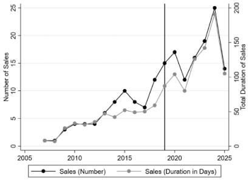

NOTE: figure/graphic rendered as an image from the PDF; its content is not machine-readable text. Caption (if any) follows as the next block.

C.2 | Additional descriptive statistics: Differentiation of platforms

Prices: Table C1 presents summary statistics for list and current prices across both platforms. List prices refer to the non-discounted price of a game. While these may evolve over time, they tend to be more stable than current prices, which are frequently adjusted, particularly during platform-wide sales promotions. On average, list prices are lower on Steam (15.50 USD) than on EGS (19.82 USD). A similar pattern holds for current prices, which include temporary discounts.

FIGURE C1 Evolution of the number and duration of sales.

TABLE C1 Average prices on Steam and EGS.

| Variable | Mean | Std dev. . | Min. | Max. | N |
| --- | --- | --- | --- | --- | --- |
| AveragelistpriceonSteam | 155 . | 1358 . | 0 | 14999 . | 8949 |
| AveragecurrentpriceonSteam | 129 . | 1166 . | 0 | 14516 . | 8949 |
| AveragelistpriceonEGS | 1982 . | 1653 . | 099 . | 14999 . | 1997 |
| AveragecurrentpriceonEGS | 1572 . | 1481 . | 021 . | 1377 . | 2001 |

NOTE: table converted from PDF layout to HTML text; cell boundaries are reconstructed. See PDF if exact alignment matters.

Note: Prices are in USD and are averages computed over the whole period at the game level.

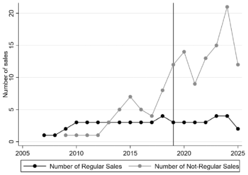

NOTE: figure/graphic rendered as an image from the PDF; its content is not machine-readable text. Caption (if any) follows as the next block.

FIGURE C2 Evolution of the number of sales (regular vs. not-regular).

TABLE C2 Impact of the entry on prices.

|  | (1) | (2) | (3) | (4) | (5) (6) |
| --- | --- | --- | --- | --- | --- |
|  | Allgames |  | Singlehoming | games | Multihominggames |
|  | Current | List | Current | List | Current List |
|  | price | price | price | price | price price |
| Post=1 × Indie | 0063 . | 0310*** . | −0 .071 | 0246** . | 2383*** 1426* . . |
| game=1 | (0105) . | (0078) . | (0104) . | (0075) . | (0641) (0558) . . |
| Post=1 × | 0090 − . | −0 .254** | 0063 − . | 0313*** − . | −0 .570 0 .811+ |
| Multiplayer=1 | (0123) . | (0080) . | (0124) . | (0080) . | (0623) (0445) . . |
| Ageinmonths | 0081** − . | 0064*** − . | −0 .087*** | 0069*** − . | 0040 0005 . . |
|  | (0025) . | (0017) . | (0026) . | (0018) . | (0121) (0092) . . |
| Agesquared | 0001*** . | 0000*** . | 0001*** . | 0000*** . | 0001*** 0001+ . . |
|  | (0000) . | (0000) . | (0000) . | (0000) . | (0000) (0000) . . |
| Controls | Y | Y | Y | Y | Y Y |
| GameFEs | Y | Y | Y | Y | Y Y |
| MonthFEs | Y | Y | Y | Y | Y Y |
| Constant | 12993*** . | 14938*** . | 12024*** . | 14056*** . | 32621* 40264*** . . |
|  | (0628) . | (0432) . | (0606) . | (0394) . | (13782) (11843) . . |
| Observations | 98077 , | 98077 , | 92798 , | 92798 , | 5279 5279 |
| Games | 5369 | 5369 | 4820 | 4820 | 269 269 |
| Within R -squared | 0064 . | 0009 . | 0063 . | 0009 . | 0112 0037 . . |

NOTE: table converted from PDF layout to HTML text; cell boundaries are reconstructed. See PDF if exact alignment matters.

Type of games: The composition of the two platforms’ catalogs also differs along several nonprice dimensions, as illustrated in Figure C5. For example, the incumbent platform Steam features a much higher share of “Indie” games compared to EGS. Steam's catalog also includes a significantly larger proportion of multiplayer games (29.6%) relative to EGS (4.1%). In terms of development team size, Steam is dominated by games created by very small teams (66% of titles are developed by teams of just one to three people). Genre composition varies as well: Steam has a strong emphasis on Adventure games (accounting for around 53% of its catalog), while EGS leans more heavily toward Action titles (38%). However, there are two important limitations to these comparisons. First, while we observe a substantial portion of EGS's catalog, our Steam sample is restricted to its most popular titles and therefore does not reflect the platform's full offering. Second, the two platforms differ in terms of maturity. Rietveld and Eggers (2018) emphasize that platform age shapes demand heterogeneity over the life cycle (e.g., in consumers’ willingness to pay and interest in novelty), which in turn affects complementors’ success and profitability. This may explain why the platforms appear quite different despite offering comparable services, such as user interfaces, features that support network effects, and regular sales promotions.

Consumer side: To comment on the heterogeneity of users affiliated with both platforms, we collect data from the web-audience tracking tool Similarweb, which provides information on the web traffic of major websites, in particular the socio-demographics of their audiences (age and gender). In our context, these are Steampowered.com and Epicgames.com. While the observation period (January to March 2024) is more recent than the timeframe analyzed in the main body of the paper, we believe the statistics remain informative. Figure C6 summarizes the demographic composition of the two audiences. Overall, the differences are minimal, suggesting that the platforms attract broadly similar user bases in terms of age and gender.

C.3 | Additional analysis: Impact of the entry on prices

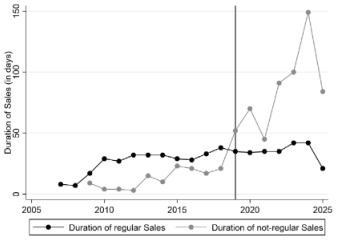

NOTE: figure/graphic rendered as an image from the PDF; its content is not machine-readable text. Caption (if any) follows as the next block.

FIGURE C3 Evolution of the duration of sales (regular vs. not-regular).

C.4 | Additional analysis: Impact of the entry on the number of users on Steam

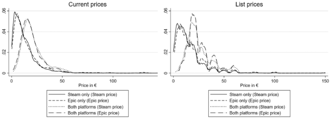

NOTE: figure/graphic rendered as an image from the PDF; its content is not machine-readable text. Caption (if any) follows as the next block.

FIGURE C4 Distribution of prices on both platforms.

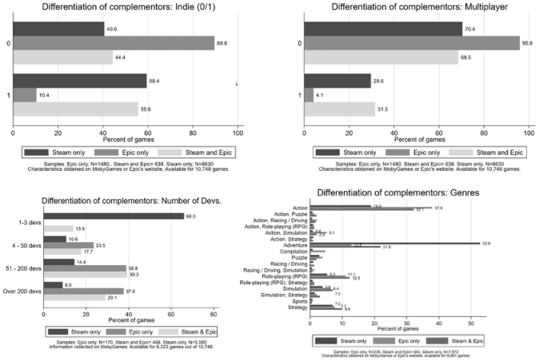

NOTE: figure/graphic rendered as an image from the PDF; its content is not machine-readable text. Caption (if any) follows as the next block.

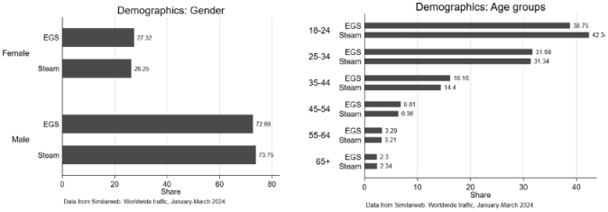

NOTE: figure/graphic rendered as an image from the PDF; its content is not machine-readable text. Caption (if any) follows as the next block.

FIGURE C6 Measures of audience on both platforms. Data from Similarweb. Worldwide traffic. Period: January to March 2024.

FIGURE C5 Differentiation of games on both platforms.

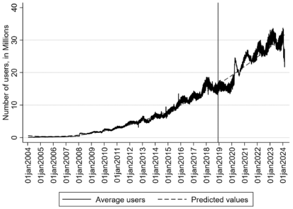

NOTE: figure/graphic rendered as an image from the PDF; its content is not machine-readable text. Caption (if any) follows as the next block.

FIGURE C7 Evolution of the number of users on Steam (2004–2024). Daily data from Steam DB. The vertical line represents the entry of EGS.

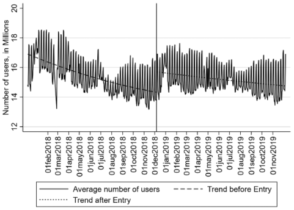

NOTE: figure/graphic rendered as an image from the PDF; its content is not machine-readable text. Caption (if any) follows as the next block.

FIGURE C8 Evolution of the number of users on Steam (Pre and Post entry). Daily data from Steam DB. The vertical line represents the entry of EGS.

APPENDIX D: ADDITIONAL DISCUSSION

D.1 | How the “cross-play” functionality could affect our study In this section, we offer a discussion of recent developments in cross-play functionality and how they relate to the mechanisms studied in our paper. The arguments we developed rest on the assumption that network effects are platform-specific—that is, consumers can only play games together if they are on the same platform. For example, Steam users can only play with other Steam users, or in the home console space, PlayStation owners with other PlayStation owners. This form of incompatibility has been a common practice in the video game industry.

Recent trends toward so-called cross-play functionality are driving a push toward interoperability among user bases. This implies that complement-level network effects have begun to operate across platform boundaries—in other words, network effects are becoming increasingly game-specific rather than platform-specific. This shift has met resistance from some console manufacturers. Most notably, Sony initially blocked cross-play entirely, later imposed charges on developers who sought to enable it, and ultimately permitted it for some games after Epic Games’ Fortnite became the most-played game on PlayStation (Partis, 2021; Warren, 2021). This highlights the reluctance of platform owners to embrace interoperability, as doing so may undermine their market power and control over user interactions (Morton et al., 2023). In addition, Sony only allowed it after one specific complementor—Epic Games—gained sufficient influence to challenge the platform's governance stance. Generally, platform owners may deliberately restrict interoperability for strategic reasons. Sony's resistance to cross-play in the video game console market is a good example. Conversely, smaller entrants might want to promote interoperability to erode the market power of incumbents.

In our empirical setting, Epic Games’ strategy illustrates this dynamic. In June 2022, it launched a cross-play tool designed to simplify cross-platform integration for game developers (Epic Online Services, 2022). This move underscores two important points: (i) implementing cross-play remains a significant technical challenge for developers, and (ii) Epic Games had strategic incentives to reduce the platform-specificity of network effects and thereby challenge Steam's dominant position. In addition to the June 2022 toolkit, Epic Games made cross-play a requirement for multiplayer titles distributed through its store in September 2024 (Benfell, 2024). However, these developments fall outside the temporal scope of our empirical analysis, as our sample ends prior to the release of these tools.

To assess whether early instances of crossplay functionality might already be present in our data—and thus potentially affect our findings—we collected information on crossplay-enabled games using a curated Wikipedia list.<sup>70</sup> Only 11 games in our sample support crossplay, suggesting that, indeed, it was not yet common during the period we analyze.<sup>71</sup> This supports the view that multiplayer games in our setting continued to rely on Steam's installed base advantage. Accordingly, the setting we study is still characterized by a lack of interoperability between platforms.

70https://en.wikipedia.org/wiki/List_of_video_games_that_support_cross-platform_play. 71Note that the small number of crossplay-enabled games prevents a proper econometric analysis of this subsample.